# Project 360

GROUP 3

*HACI MEHMET İNCE,BERNA HIZLI,MUSTAFA ALPER ÇELİK,KADİR AHMET AKSU,SELEN CAKA

***INTRODUCTION

It is difficult for people living in crowded cities and having challenging business lives to have time for traditional shopping. Additionally, the rent expenses of stores in shopping centers have a negative impact on the price of goods. Therefore, meeting the needs from e-commerce stores comes into fashion nowadays, which leads supplier companies to invest in e-commerce websites rather than increasing the number of physical stores. Thus, consumers can buy economically while firms can reach large market shares.

Companies may have difficulty in keeping the inventory levels sufficient and transporting the products at the proper time while meeting the demands of the customers. Therefore, it is necessary to forecast the demands of the each product for the next days via statistical calculations. Analyzing the data in hand in a meaningful way, which is done by statistical approaches, and predicting the demand for future is essential in increasing the revenue.

The content of statistical forecasting and time series class overlaps with this problem. One of the biggest e-commerce companies Trendyol was selected as the project case at 2020 Spring term. The study was conducted for eight different products from different categories. Throughout thirty days, the data provided by Trendyol was examined. The sold counts for two days later were predicted based on the data which was updated daily. Predicting the number of sales for 48 hours later with the help of statistical calculations helps the vendor to take an action.

```r
# install the required packages first
require(jsonlite)
require(httr)
require(data.table)
require(ellipsis)
require(forecast)
require(stats)
require(xts)
```

```r
require(zoo)
require(ggplot2)
# DONT CHANGE FUNCTIONS
get_token <- function(username, password, url_site){
    11
    post_body = list(username=username,password=password)
    post_url_string = paste0(url_site,'/token/')
    result = POST(post_url_string, body = post_body)
    # error handling (wrong credentials)
    if(result$status_code==400){
        print('Check your credentials')
        return(0)
    }
    else if (result$status_code==201){
        output = content(result)
        token = output$key
    }

    return(token)
}
get_data <- function(start_date='2020-03-20', token, url_site){

    post_body = list(start_date=start_date,username=username,password=password)
    post_url_string = paste0(url_site,'/dataset/')

    header = add_headers(c(Authorization=paste('Token',token,sep=' ')))
    result = GET(post_url_string, header, body = post_body)
    output = content(result)
    data = data.table::rbindlist(output)
    data[,event_date:=as.Date(event_date)]
    data = data[order(product_content_id,event_date)]
    return(data)
}
check_format <- function(predictions){

    if(is.data.frame(predictions) | is.data.frame(predictions)){
        if(all(c('product_content_id','forecast') %in% names(predictions))){
            if(is.numeric(predictions$forecast)){
                print("Format OK")
                return(TRUE)
            } else {
                print("forecast information is not numeric")
                return(FALSE)
            }
        } else {
            print("Wrong column names. Please provide 'product_content_id' and 'forecast' columns")
            return(FALSE)
        }

    } else {
        print("Wrong format. Please provide data.frame or data.table object")
        return(FALSE)
    }

}
send_one_forecast <- function(product_id, forecast ,token, url_site, submit_now=F){

    post_body = list(username=username,password=password)
    post_url_string = paste0(url_site,'/submission/')

    header = add_headers(c(Authorization=paste('Token',token,sep=' ')))
    result = GET(post_url_string, header, body = post_body)

    output = content(result)
    data = data.table::rbindlist(output)
    data[,date:=timestamp(date,quiet = TRUE)]
    aaa = tail(data[order(date)][,"submission"],1)

    print("Ex-submission:")
    print(aaa)

    split1 = strsplit(aaa$submission,"}")
    split2 = unlist(strsplit(unlist(split1),"'"))

    ps = c()
    nos = c()

    for(a in 1:7){
        i = 3
        ps = c(ps,split2[2*a])
        tmp = split2[2*a+1]
        l = nchar(tmp)
        tx = as.double(substr(tmp,i,l-2))
        nos = c(nos,tx)
    }

    i = 3
    ps = c(ps,split2[16])
    tmp = split2[17]
    l = nchar(tmp)
    tx = as.double(substr(tmp,i,l))
    nos = c(nos,tx)

    predictions = data.table("product_content_id" = ps,"forecast" = nos)

    print("Ex-Predictions:")
    print(predictions)

    idx = (predictions$product_content_id == product_id)
    predictions[idx,]$forecast = forecast

    format_check=check_format(predictions)
    if(!format_check){
        return(FALSE)
    }

    post_string="list("
    for(i in 1:nrow(predictions)){
        post_string=sprintf("%s'%s'=%s",post_string,predictions$product_content_id[i],predictions$forecast[i])
        if(i<nrow(predictions)){
            post_string=sprintf("%s,",post_string)
        } else {
            post_string=sprintf("%s)",post_string)
        }
    }

    submission = eval(parse(text=post_string))
    json_body = jsonlite::toJSON(submission, auto_unbox = TRUE)
    submission=list(submission=json_body)

    print("")
    print("")
    print("New submission:")
    print(submission)
    print("New Predictions:")
    print(predictions)

    if(!submit_now){
        print("You did not submit.")
        return(FALSE)
    }

    header = add_headers(c(Authorization=paste('Token',token,sep=' ')))
    post_url_string = paste0(url_site,'/submission/')
    result = POST(post_url_string, header, body=submission)

    if (result$status_code==201){
        print("")
        print("SUCCESSFULLY SUBMÄ°TTED. Below you can see the details of your submission")
        print("")
        print(content(result))
    } else {
        print("Could NOT submit. Please check the error message below, contact the assistant if needed.")
    }

    print("")
    print("")
    print(content(result))

}

# DONT CHANGE
subm_url = 'http://167.172.183.67'
username = "Group3"
password = "cy6DmxzXZEsqDcnF"
#token = get_token(username=username, password=password, url=subm_url)
token = "9cd307d666be12b6aa909786ad3c002815f1f8ce"
data = get_data(token=token,url=subm_url)
mydata = data[data$product_content_id == "31515569" ,]
mydata2=data[data$product_content_id == "6676673" ,]
mydata3= data[data$product_content_id == "4066298" ,]
mydata4=data[data$product_content_id == "7061886" ,]
mydata5=data[data$product_content_id == "32939029" ,]
kulaklık<-mydata2[54:427]
tayt<-mydata[146:427]
pamukluhavlu<-mydata3[133:427]
es<-mydata4[89:427]
dişf<-mydata5[208:427]
product.data= data[data$product_content_id == "85004" ,]
```

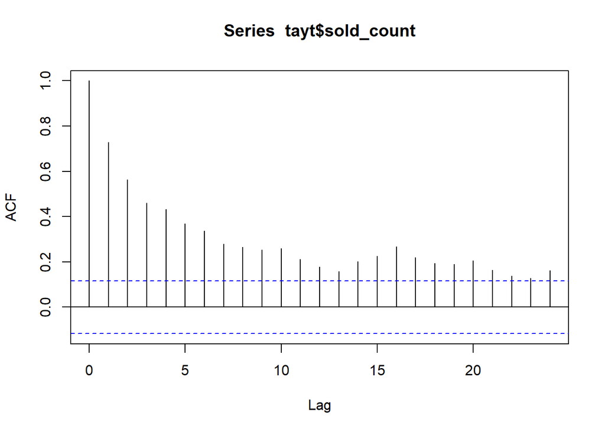

```r
tayt$meanthree<-0
for(i in 0:279){
for(j in 0:2){
tayt$meanthree[3+i]<- tayt$meanthree[3+i]+tayt$sold_count[1+i+j]
}
tayt$meanthree[3+i]<- tayt$meanthree[3+i]/3
}
tayt$meanthreetwo[5:282]<-tayt$meanthree[3:280]
tayt$meanweek<-0
for(i in 0:275){
for(j in 0:6){
tayt$meanweek[7+i]<- tayt$meanweek[7+i]+tayt$sold_count[1+i+j]
}
tayt$meanweek[7+i]<- tayt$meanweek[7+i]/7
}
tayt$meanweektwo[9:282]<-tayt$meanweek[7:280]

tayt$one[2:282]<-tayt$sold_count[1:281]
tayt$two[3:282]<-tayt$sold_count[1:280]
tayt$three[4:282]<-tayt$sold_count[1:279]
tayt$four[5:282]<-tayt$sold_count[1:278]
tayt$five[6:282]<-tayt$sold_count[1:277]
tayt$six[7:282]<-tayt$sold_count[1:276]
tayt$seven[8:282]<-tayt$sold_count[1:275]

tayt$visit[3:282]<-tayt$visit_count[1:280]
tayt$favored[3:282]<-tayt$favored_count[1:280]
tayt$basket[3:282]<-tayt$basket_count[1:280]
tayt$category[3:282]<-tayt$category_sold[1:280]
tayt$category_brand[3:282]<-tayt$category_brand_sold[1:280]
tayt$category_visit2[3:282]<-tayt$category_visits[1:280]
tayt$ty[3:282]<-tayt$ty_visits[1:280]
tayt$pricetwo[3:282]<-tayt$price[1:280]
tayt$priceone [2:282]<-tayt$price[1:281]
tayt[,event_date:=as.POSIXct(tayt$event_date,format='%Y-%m-%d' ) ]
tayt$date<- weekdays(as.Date(tayt$event_date))
test_data=tail(tayt,50)
data=tayt[1:(nrow(tayt)-50)]
acf(tayt$sold_count)
```

*Firstly,we add lag variables because what is excepted us is that estimating the number of sales tomorrow, using data from yesterday. Therefore, We also added the variables of 2 days ago to data table. Also, we added the sold count of 3,4,5,6 and 7 days ago to data table. We added the sold counts of last three days and the sold counts of last seven days. We added the price of tights of yesterday and 2 days ago. Additionaly, we added a variable that indicates what day of the week it is. Using as.POSIXct funciton to convert event date of tights’ data to represent date/times. Then, we create test and train data. We created models by using train data. Then, we evaluated the performance of the models and decided which model is we use by using test data. First, we try to find seasonality for tights’ data. We use autocorrelation function to find seansonality. But we cannot observe any seasonality.

```r
lmodel=lm(formula=sold_count ~ two,data=tayt[126:232])
summary(lmodel)
```

```
##
## Call:
## lm(formula = sold_count ~ two, data = tayt[126:232])
##
## Residuals:
##     Min      1Q  Median      3Q     Max
## -633.23 -138.57  -27.64   64.27 1206.37
##
## Coefficients:
##              Estimate Std. Error t value Pr(>|t|)
## (Intercept) 258.10164   53.37867   4.835 4.57e-06 ***
## two           0.55013    0.08202   6.707 1.03e-09 ***
## ---
## Signif. codes:  0 '***' 0.001 '**' 0.01 '*' 0.05 '.' 0.1 ' ' 1
##
## Residual standard error: 256.6 on 105 degrees of freedom
## Multiple R-squared:  0.2999, Adjusted R-squared:  0.2933
## F-statistic: 44.99 on 1 and 105 DF,  p-value: 1.029e-09
```

```r
lmodel=lm(formula=sold_count ~ two+visit+favored+basket+category+category_brand+category_visit2+ty,data=tayt[126:232])
summary(lmodel)
```

```
##
## Call:
## lm(formula = sold_count ~ two + visit + favored + basket + category +
##     category_brand + category_visit2 + ty, data = tayt[126:232])
##
## Residuals:
##     Min      1Q  Median      3Q     Max
## -775.13 -111.22  -26.10   59.14 1297.70
##
## Coefficients:
##                   Estimate Std. Error t value Pr(>|t|)
## (Intercept)      3.722e+02  9.201e+01   4.045 0.000104 ***
## two              1.990e-01  2.147e-01   0.927 0.356300
## visit           -2.476e-02  8.252e-03  -3.000 0.003418 **
## favored          1.894e-01  1.165e-01   1.625 0.107313
## basket           9.805e-02  4.318e-02   2.271 0.025356 *
## category        -2.527e-01  1.666e-01  -1.517 0.132476
## category_brand   1.806e+00  1.270e+00   1.422 0.158217
## category_visit2  1.190e-04  1.974e-04   0.603 0.548207
## ty               3.522e-06  2.710e-06   1.300 0.196784
## ---
## Signif. codes:  0 '***' 0.001 '**' 0.01 '*' 0.05 '.' 0.1 ' ' 1
##
## Residual standard error: 242.6 on 98 degrees of freedom
## Multiple R-squared:  0.4161, Adjusted R-squared:  0.3685
## F-statistic: 8.731 on 8 and 98 DF,  p-value: 6.139e-09
```

```r
lmodel=lm(formula=sold_count ~ as.factor(date)+two+three+four+five+six+seven +visit+favored+basket+category+category_brand+meanweektwo,data)
summary(lmodel)
```

```
##
## Call:
## lm(formula = sold_count ~ as.factor(date) + two + three + four +
##     five + six + seven + visit + favored + basket + category +
##     category_brand + meanweektwo, data = data)
##
## Residuals:
##     Min      1Q  Median      3Q     Max
## -760.53 -117.40  -40.77   49.10 1658.29
##
## Coefficients:
##                            Estimate Std. Error t value Pr(>|t|)
## (Intercept)              188.934135  67.994951   2.779  0.00597 **
## as.factor(date)Cumartesi -72.811931  68.693996  -1.060  0.29042
## as.factor(date)Çarşamba   66.984073  68.549665   0.977  0.32964
## as.factor(date)Pazar     -57.468603  69.561986  -0.826  0.40968
## as.factor(date)Pazartesi  -1.503707  69.975076  -0.021  0.98288
## as.factor(date)Perşembe   28.863671  68.329044   0.422  0.67316
## as.factor(date)Salı       57.832667  69.304989   0.834  0.40499
## two                        0.457698   0.140710   3.253  0.00134 **
## three                      0.074576   0.120713   0.618  0.53740
## four                       0.219685   0.137026   1.603  0.11042
## five                      -0.015157   0.124017  -0.122  0.90285
## six                       -0.003082   0.130151  -0.024  0.98113
## seven                      0.026159   0.156576   0.167  0.86748
## visit                     -0.005306   0.003365  -1.577  0.11643
## favored                    0.155785   0.070044   2.224  0.02723 *
## basket                     0.040075   0.013463   2.977  0.00327 **
## category                  -0.152672   0.085872  -1.778  0.07690 .
## category_brand             1.248928   0.701007   1.782  0.07629 .
## meanweektwo               -0.214350   0.575888  -0.372  0.71012
## ---
## Signif. codes:  0 '***' 0.001 '**' 0.01 '*' 0.05 '.' 0.1 ' ' 1
##
## Residual standard error: 271.5 on 205 degrees of freedom
##   (8 observations deleted due to missingness)
## Multiple R-squared:  0.4754, Adjusted R-squared:  0.4293
## F-statistic: 10.32 on 18 and 205 DF,  p-value: < 2.2e-16
```

```r
lmodel=lm(formula=sold_count ~ as.factor(date)+two+three+four+five+six+seven +visit+favored+basket+category+category_brand+category_visit2+ty+meanweektwo,data=tayt[126:232])
summary(lmodel)
```

```
##
## Call:
## lm(formula = sold_count ~ as.factor(date) + two + three + four +
##     five + six + seven + visit + favored + basket + category +
##     category_brand + category_visit2 + ty + meanweektwo, data = tayt[126:232])
##
## Residuals:
##     Min      1Q  Median      3Q     Max
## -669.44 -126.33  -29.38   80.26 1156.26
##
## Coefficients:
##                            Estimate Std. Error t value Pr(>|t|)
## (Intercept)               2.955e+02  1.269e+02   2.328   0.0223 *
## as.factor(date)Cumartesi -5.839e+01  9.555e+01  -0.611   0.5428
## as.factor(date)Çarşamba   1.261e+02  9.419e+01   1.339   0.1842
## as.factor(date)Pazar      1.431e+01  9.945e+01   0.144   0.8859
## as.factor(date)Pazartesi -6.641e+01  1.033e+02  -0.643   0.5222
## as.factor(date)Perşembe   4.124e+01  9.723e+01   0.424   0.6725
## as.factor(date)Salı       1.266e+02  1.016e+02   1.245   0.2163
## two                       3.067e-01  2.947e-01   1.041   0.3010
## three                    -7.378e-02  1.910e-01  -0.386   0.7003
## four                      6.293e-02  2.034e-01   0.309   0.7578
## five                      1.379e-01  1.717e-01   0.803   0.4241
## six                       1.682e-01  1.974e-01   0.852   0.3966
## seven                    -1.007e-01  2.312e-01  -0.435   0.6643
## visit                    -2.213e-02  8.809e-03  -2.512   0.0139 *
## favored                   1.666e-01  1.232e-01   1.352   0.1798
## basket                    8.935e-02  4.655e-02   1.919   0.0583 .
## category                 -1.655e-01  1.844e-01  -0.897   0.3721
## category_brand            1.242e+00  1.405e+00   0.884   0.3790
## category_visit2           1.128e-04  2.030e-04   0.556   0.5799
## ty                        2.603e-06  2.862e-06   0.910   0.3656
## meanweektwo              -2.277e-01  8.568e-01  -0.266   0.7911
## ---
## Signif. codes:  0 '***' 0.001 '**' 0.01 '*' 0.05 '.' 0.1 ' ' 1
##
## Residual standard error: 242.5 on 86 degrees of freedom
## Multiple R-squared:  0.4881, Adjusted R-squared:  0.369
## F-statistic:   4.1 on 20 and 86 DF,  p-value: 2.284e-06
```

```r
lmodel=lm(formula=sold_count ~ as.factor(date)+two+three+four+five+six+seven +visit+favored+basket+category+category_brand+category_visit2+ty+meanweektwo+priceone+pricetwo,data=tayt[126:232])
summary(lmodel)
```

```
##
## Call:
## lm(formula = sold_count ~ as.factor(date) + two + three + four +
##     five + six + seven + visit + favored + basket + category +
##     category_brand + category_visit2 + ty + meanweektwo + priceone +
##     pricetwo, data = tayt[126:232])
##
## Residuals:
##     Min      1Q  Median      3Q     Max
## -633.88  -91.79  -28.30   87.03  633.47
##
## Coefficients:
##                            Estimate Std. Error t value Pr(>|t|)
## (Intercept)               2.834e+03  9.055e+02   3.130  0.00240 **
## as.factor(date)Cumartesi -3.246e+01  8.170e+01  -0.397  0.69216
## as.factor(date)Çarşamba   1.192e+02  8.074e+01   1.476  0.14367
## as.factor(date)Pazar      3.334e+01  8.498e+01   0.392  0.69578
## as.factor(date)Pazartesi -7.911e+01  8.880e+01  -0.891  0.37552
## as.factor(date)Perşembe   4.171e+01  8.325e+01   0.501  0.61768
## as.factor(date)Salı       1.442e+02  8.766e+01   1.645  0.10364
## two                       1.573e-02  2.651e-01   0.059  0.95283
## three                    -1.722e-01  1.693e-01  -1.017  0.31186
## four                      9.895e-02  1.746e-01   0.567  0.57242
## five                      6.248e-02  1.474e-01   0.424  0.67277
## six                       2.921e-02  1.703e-01   0.172  0.86424
## seven                    -1.918e-01  1.979e-01  -0.969  0.33523
## visit                    -1.992e-02  7.523e-03  -2.648  0.00966 **
## favored                   1.528e-01  1.069e-01   1.429  0.15669
## basket                    7.094e-02  3.994e-02   1.776  0.07936 .
## category                 -1.262e-01  1.578e-01  -0.800  0.42620
## category_brand            9.303e-01  1.203e+00   0.773  0.44158
## category_visit2           1.739e-05  1.750e-04   0.099  0.92109
## ty                        5.935e-06  2.584e-06   2.296  0.02415 *
## meanweektwo               3.289e-01  7.400e-01   0.444  0.65784
## priceone                 -2.167e+02  4.043e+01  -5.358 7.23e-07 ***
## pricetwo                  1.499e+02  4.424e+01   3.389  0.00107 **
## ---
## Signif. codes:  0 '***' 0.001 '**' 0.01 '*' 0.05 '.' 0.1 ' ' 1
##
## Residual standard error: 206.8 on 84 degrees of freedom
## Multiple R-squared:  0.6363, Adjusted R-squared:  0.5411
## F-statistic:  6.68 on 22 and 84 DF,  p-value: 7.037e-11
```

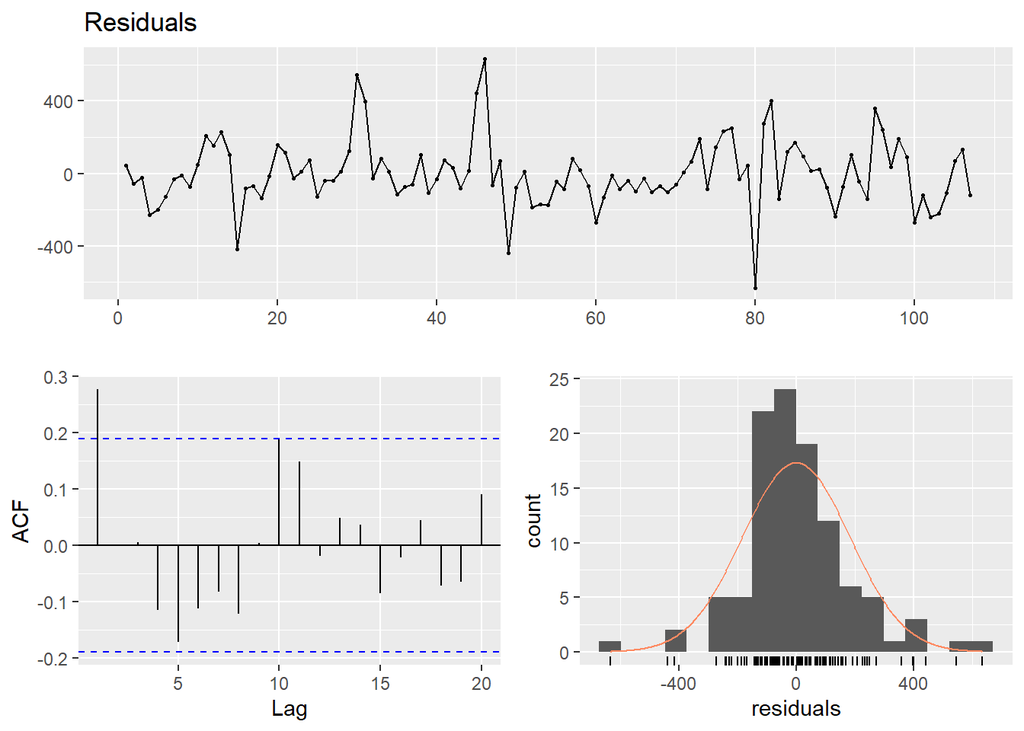

```
##
##  Breusch-Godfrey test for serial correlation of order up to 26
##
## data:  Residuals
## LM test = 35.712, df = 26, p-value = 0.0971
```

```r
checkresiduals(lmodel)
```

```r
test_data[,predicted:=predict(lmodel,test_data)]
```

*Then, we apply linear regression to tights’ daily sold count. We don’t use first 125 observations of train data to build linear model. Because, value of category visit and value of trendyol visit are missing in the first 125 observations. We try a few more models and select the one having higher R-adjusted value. We use checkresiduals function. P-value is equal to 0.0971. This value is not too small. White noise exists.

```r
for(i in 1:50){
data_ts=ts(tayt $sold_count[1:(i+232-2)],frequency = 1)
arima_model=auto.arima(data_ts)
predictions=forecast(arima_model,h=2)
predicted_arima<-as.vector(predictions$mean)
test_data$predicted_arima[i]<-predicted_arima[2]
}
for(i in 1:50){
xreg = basket=tayt$basket[1:(i+232-2)]
data_ts=ts(tayt $sold_count[1:(i+232-2)],frequency = 1)
arima_model=auto.arima(data_ts,xreg=xreg)
predictions=forecast(arima_model,h=2,xreg= tayt$basket[(i+232-1):(i+232)])
predicted_arima<-as.vector(predictions$mean)
test_data$predicted_lr_arima[i]<-predicted_arima[2]
}
```

*Therefore, when we convert data to time series by using time series function, we equalized the frequency value to 1 because we don’t observe any seasonality by using autocorrelation function. Then, we create a for loop for test data. We create “data_ts” to find best arima model by using ts function. We update “data_ts” with the sold counts until the previous day and we find the best arima model every time by using auto.arima function. We make 2-day forecasts each time and add the forecast of the 2nd day to the test data as predict_arima and predict_lr_arima. As explained above, we build to models without external regressors and with external regressors.

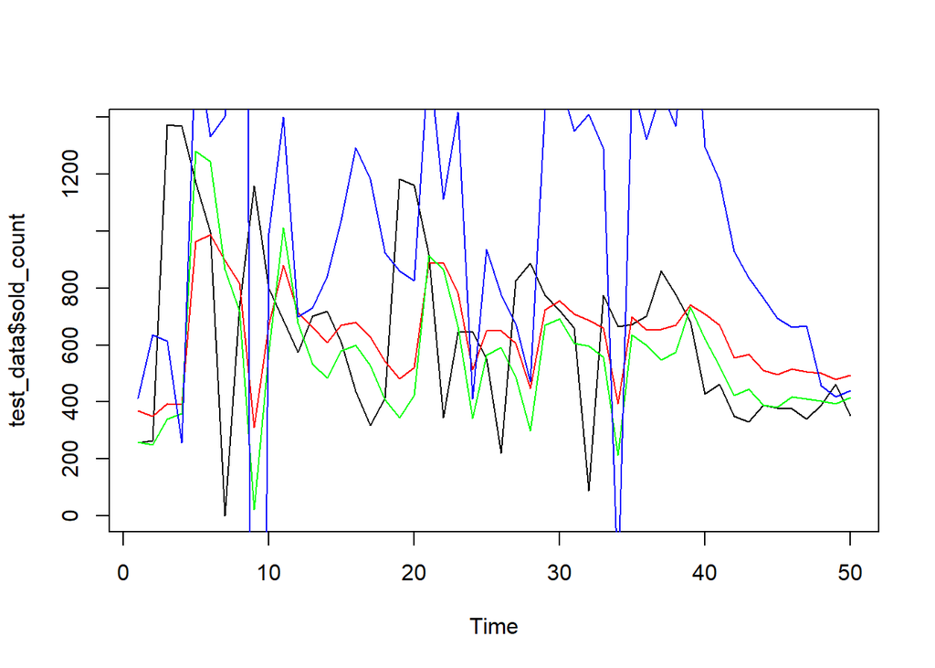

```r
ts.plot(test_data$sold_count)
lines(test_data$predicted_arima,col="red")
lines(test_data$predicted_lr_arima,col="green")
lines(test_data$predicted,col="blue")
```

```r
pred_datatable=test_data[,.(sold_count,predicted,predicted_arima,predicted_lr_arima)]
melted=melt(pred_datatable,id.vars=c(1))
summary_result=melted[,list(se=(value-sold_count)^2,
                            ad=abs(value-sold_count),
                            ape=abs(value-sold_count)/sold_count,sold_count),by=list(variable)]

summary_result=summary_result[,list(mse=mean(se),mad=mean(ad),mape=mean(ape)),by=list(variable)]
summary_result
```

```
##              variable       mse      mad mape
## 1:          predicted 3513221.0 869.6435  Inf
## 2:    predicted_arima  125454.5 244.4795  Inf
## 3: predicted_lr_arima  149467.1 248.0591  Inf
```

```r
test_data2 <- test_data[-c(7), ]
pred_datatable=test_data2[,.(sold_count,predicted,predicted_arima,predicted_lr_arima)]
melted=melt(pred_datatable,id.vars=c(1))
summary_result=melted[,list(se=(value-sold_count)^2,
                            ad=abs(value-sold_count),
                            ape=abs(value-sold_count)/sold_count,sold_count),by=list(variable)]

summary_result=summary_result[,list(mse=mean(se),mad=mean(ad),mape=mean(ape)),by=list(variable)]
summary_result
```

```
##              variable       mse      mad      mape
## 1:          predicted 3544783.5 858.7714 1.5868093
## 2:    predicted_arima  111578.7 231.1542 0.5046300
## 3: predicted_lr_arima  137250.9 235.4704 0.4341725
```

*When we compare their performances, Arima model with external regressors has the lowest mape. Therefore, we select this model to predict tomorrow sold count of tights.

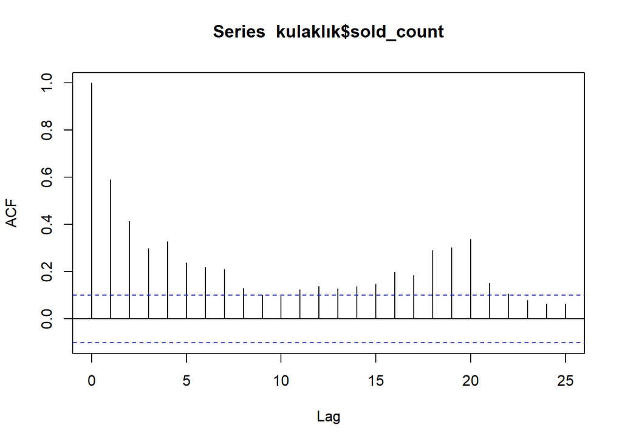

```r
kulaklık$meanthree<-0
for(i in 0:371){
for(j in 0:2){
kulaklık$meanthree[3+i]<- kulaklık$meanthree[3+i]+kulaklık$sold_count[1+i+j]
}
kulaklık$meanthree[3+i]<- kulaklık$meanthree[3+i]/3
}
kulaklık$meanthreetwo[5:374]<-kulaklık$meanthree[3:372]
kulaklık$meanweek<-0
for(i in 0:367){
for(j in 0:6){
kulaklık$meanweek[7+i]<- kulaklık$meanweek[7+i]+ kulaklık$sold_count[1+i+j]
}
kulaklık$meanweek[7+i]<- kulaklık$meanweek[7+i]/7
}
kulaklık$meanweektwo<-0
kulaklık$meanweektwo[9:374]<- kulaklık$meanweek[7:372]

kulaklık$one[2:374]<- kulaklık$sold_count[1:373]
kulaklık$two[3:374]<- kulaklık$sold_count[1:372]
kulaklık$three[4:374]<- kulaklık$sold_count[1:371]
kulaklık$four[5:374]<- kulaklık$sold_count[1:370]
kulaklık$five[6:374]<- kulaklık$sold_count[1:369]
kulaklık$six[7:374]<- kulaklık$sold_count[1:368]
kulaklık$seven[8:374]<- kulaklık$sold_count[1:367]

kulaklık$visit[3:374]<- kulaklık$visit_count[1:372]
kulaklık$favored[3:374]<- kulaklık$favored_count[1:372]
kulaklık$basket[3:374]<- kulaklık$basket_count[1:372]
kulaklık$category[3:374]<- kulaklık$category_sold[1:372]
kulaklık$category_brand[3:374]<- kulaklık$category_brand_sold[1:372]
kulaklık$category_visit2[3:374]<- kulaklık$category_visits[1:372]
kulaklık$ty[3:374]<- kulaklık$ty_visits[1:372]
kulaklık$pricetwo[3:374]<- kulaklık$price[1:372]
kulaklık$priceone[2:374]<- kulaklık$price[1:373]
kulaklık[,event_date:=as.POSIXct(kulaklık$event_date,format='%Y-%m-%d' ) ]
kulaklık$date<- weekdays(as.Date(kulaklık$event_date))
test_data=tail(kulaklık,50)
data=kulaklık[1:(nrow(kulaklık)-50)]
acf(kulaklık$sold_count)
```

*We try to find seasonality for earphone’s data. We use autocorrelation function to find seansonality. But we cannot observe any seasonality.

```r
lmodel=lm(formula=sold_count ~ two,data=kulaklık[218:374])
summary(lmodel)
```

```
##
## Call:
## lm(formula = sold_count ~ two, data = kulaklık[218:374])
##
## Residuals:
##     Min      1Q  Median      3Q     Max
## -426.43  -77.87  -18.01   54.51  945.75
##
## Coefficients:
##              Estimate Std. Error t value Pr(>|t|)
## (Intercept) 173.81419   28.35431    6.13 6.98e-09 ***
## two           0.54764    0.06712    8.16 1.08e-13 ***
## ---
## Signif. codes:  0 '***' 0.001 '**' 0.01 '*' 0.05 '.' 0.1 ' ' 1
##
## Residual standard error: 150.3 on 155 degrees of freedom
## Multiple R-squared:  0.3005, Adjusted R-squared:  0.296
## F-statistic: 66.58 on 1 and 155 DF,  p-value: 1.079e-13
```

```r
lmodel=lm(formula=sold_count ~ two+visit+favored+basket+category+category_brand+category_visit2+ty,data=kulaklık [218:374])
summary(lmodel)
```

```
##
## Call:
## lm(formula = sold_count ~ two + visit + favored + basket + category +
##     category_brand + category_visit2 + ty, data = kulaklık[218:374])
##
## Residuals:
##     Min      1Q  Median      3Q     Max
## -390.15  -79.45  -15.24   53.52  932.04
##
## Coefficients:
##                   Estimate Std. Error t value Pr(>|t|)
## (Intercept)      2.343e+02  5.756e+01   4.070 7.64e-05 ***
## two              4.358e-01  1.912e-01   2.279   0.0241 *
## visit           -4.157e-04  2.575e-03  -0.161   0.8720
## favored          2.502e-01  1.855e-01   1.349   0.1794
## basket           1.406e-02  4.530e-02   0.310   0.7566
## category         3.904e-02  2.010e-02   1.942   0.0540 .
## category_brand  -2.336e-02  1.240e-01  -0.188   0.8508
## category_visit2 -2.639e-04  2.539e-04  -1.039   0.3004
## ty              -7.470e-07  6.081e-07  -1.228   0.2212
## ---
## Signif. codes:  0 '***' 0.001 '**' 0.01 '*' 0.05 '.' 0.1 ' ' 1
##
## Residual standard error: 148.4 on 148 degrees of freedom
## Multiple R-squared:  0.3493, Adjusted R-squared:  0.3142
## F-statistic: 9.932 on 8 and 148 DF,  p-value: 5.195e-11
```

```r
lmodel=lm(formula=sold_count ~ as.factor(date)+two+three+four+five+six+seven +visit+favored+basket+category+category_brand+meanweektwo,data)
summary(lmodel)
```

```
##
## Call:
## lm(formula = sold_count ~ as.factor(date) + two + three + four +
##     five + six + seven + visit + favored + basket + category +
##     category_brand + meanweektwo, data = data)
##
## Residuals:
##     Min      1Q  Median      3Q     Max
## -1979.8  -141.4   -29.2    64.0  6957.9
##
## Coefficients:
##                            Estimate Std. Error t value Pr(>|t|)
## (Intercept)               1.892e+02  1.012e+02   1.870   0.0624 .
## as.factor(date)Cumartesi -1.177e+02  1.258e+02  -0.936   0.3500
## as.factor(date)Çarşamba  -1.768e+02  1.262e+02  -1.401   0.1624
## as.factor(date)Pazar     -2.185e+02  1.259e+02  -1.736   0.0837 .
## as.factor(date)Pazartesi -2.172e+02  1.266e+02  -1.715   0.0874 .
## as.factor(date)Perşembe  -1.012e+02  1.264e+02  -0.801   0.4237
## as.factor(date)Salı      -2.095e+02  1.260e+02  -1.663   0.0974 .
## two                      -2.571e-01  1.232e-01  -2.088   0.0376 *
## three                     4.588e-02  8.670e-02   0.529   0.5970
## four                      2.261e-01  9.777e-02   2.313   0.0214 *
## five                      6.894e-02  8.652e-02   0.797   0.4262
## six                       9.518e-02  9.185e-02   1.036   0.3010
## seven                     1.788e-01  1.088e-01   1.643   0.1014
## visit                     2.330e-02  5.087e-03   4.579 6.86e-06 ***
## favored                   2.463e-01  1.428e-01   1.725   0.0856 .
## basket                   -3.807e-02  5.022e-02  -0.758   0.4489
## category                 -8.357e-01  7.448e-01  -1.122   0.2627
## category_brand            5.651e+00  5.225e+00   1.082   0.2803
## meanweektwo              -6.148e-01  4.175e-01  -1.472   0.1420
## ---
## Signif. codes:  0 '***' 0.001 '**' 0.01 '*' 0.05 '.' 0.1 ' ' 1
##
## Residual standard error: 593 on 298 degrees of freedom
##   (7 observations deleted due to missingness)
## Multiple R-squared:  0.3593, Adjusted R-squared:  0.3206
## F-statistic: 9.283 on 18 and 298 DF,  p-value: < 2.2e-16
```

```r
lmodel=lm(formula=sold_count ~ as.factor(date)+two+three+four+five+six+seven +visit+favored+basket+category+category_brand+category_visit2+ty+meanweektwo,data=kulaklık[218:374])
summary(lmodel)
```

```
##
## Call:
## lm(formula = sold_count ~ as.factor(date) + two + three + four +
##     five + six + seven + visit + favored + basket + category +
##     category_brand + category_visit2 + ty + meanweektwo, data = kulaklık[218:374])
##
## Residuals:
##     Min      1Q  Median      3Q     Max
## -329.90  -66.24  -16.55   52.70  809.94
##
## Coefficients:
##                            Estimate Std. Error t value Pr(>|t|)
## (Intercept)               2.733e+02  8.684e+01   3.147  0.00203 **
## as.factor(date)Cumartesi -1.233e+01  4.443e+01  -0.278  0.78178
## as.factor(date)Çarşamba   8.217e+01  4.470e+01   1.838  0.06823 .
## as.factor(date)Pazar      3.668e+01  4.623e+01   0.793  0.42897
## as.factor(date)Pazartesi  9.442e+01  4.681e+01   2.017  0.04565 *
## as.factor(date)Perşembe   1.768e+01  4.417e+01   0.400  0.68951
## as.factor(date)Salı       1.524e+02  4.636e+01   3.288  0.00128 **
## two                       6.657e-01  2.189e-01   3.041  0.00283 **
## three                     9.817e-02  1.430e-01   0.687  0.49345
## four                     -2.506e-03  1.509e-01  -0.017  0.98678
## five                     -5.772e-02  1.469e-01  -0.393  0.69507
## six                       1.066e-01  1.669e-01   0.638  0.52429
## seven                     6.336e-02  1.856e-01   0.341  0.73332
## visit                    -8.152e-04  2.549e-03  -0.320  0.74959
## favored                   1.950e-01  1.823e-01   1.070  0.28671
## basket                    1.002e-02  4.518e-02   0.222  0.82486
## category                  3.819e-02  1.967e-02   1.941  0.05432 .
## category_brand            8.129e-04  1.269e-01   0.006  0.99490
## category_visit2          -2.323e-04  2.460e-04  -0.944  0.34677
## ty                       -1.196e-06  6.288e-07  -1.901  0.05936 .
## meanweektwo              -5.192e-01  7.036e-01  -0.738  0.46187
## ---
## Signif. codes:  0 '***' 0.001 '**' 0.01 '*' 0.05 '.' 0.1 ' ' 1
##
## Residual standard error: 141.1 on 136 degrees of freedom
## Multiple R-squared:  0.4589, Adjusted R-squared:  0.3794
## F-statistic: 5.768 on 20 and 136 DF,  p-value: 1.245e-10
```

```r
lmodel=lm(formula=sold_count ~ as.factor(date)+two+three+four+five+six+seven +visit+favored+basket+category+category_brand+category_visit2+ty+meanweektwo+priceone+pricetwo,data=kulaklık[218:374])
summary(lmodel)
```

```
##
## Call:
## lm(formula = sold_count ~ as.factor(date) + two + three + four +
##     five + six + seven + visit + favored + basket + category +
##     category_brand + category_visit2 + ty + meanweektwo + priceone +
##     pricetwo, data = kulaklık[218:374])
##
## Residuals:
##     Min      1Q  Median      3Q     Max
## -310.76  -66.82   -7.39   58.09  693.67
##
## Coefficients:
##                            Estimate Std. Error t value Pr(>|t|)
## (Intercept)              -1.142e+02  3.187e+02  -0.358 0.720538
## as.factor(date)Cumartesi -1.913e+01  4.168e+01  -0.459 0.646944
## as.factor(date)Çarşamba   5.157e+01  4.213e+01   1.224 0.223116
## as.factor(date)Pazar      1.439e+01  4.332e+01   0.332 0.740249
## as.factor(date)Pazartesi  7.806e+01  4.401e+01   1.774 0.078389 .
## as.factor(date)Perşembe   1.666e+01  4.128e+01   0.404 0.687044
## as.factor(date)Salı       1.654e+02  4.349e+01   3.803 0.000217 ***
## two                       7.857e-01  2.189e-01   3.590 0.000463 ***
## three                     5.934e-02  1.335e-01   0.445 0.657382
## four                     -4.180e-02  1.408e-01  -0.297 0.767053
## five                     -3.401e-02  1.375e-01  -0.247 0.805073
## six                       1.860e-01  1.567e-01   1.187 0.237289
## seven                     5.099e-03  1.733e-01   0.029 0.976566
## visit                    -9.017e-05  2.432e-03  -0.037 0.970476
## favored                   3.399e-01  1.735e-01   1.959 0.052170 .
## basket                    3.174e-04  4.264e-02   0.007 0.994072
## category                  3.489e-02  1.837e-02   1.899 0.059701 .
## category_brand            2.537e-02  1.183e-01   0.215 0.830445
## category_visit2          -2.473e-04  2.348e-04  -1.053 0.294249
## ty                       -1.971e-06  9.158e-07  -2.152 0.033188 *
## meanweektwo              -4.832e-01  6.565e-01  -0.736 0.462992
## priceone                 -1.316e+01  3.147e+00  -4.182 5.19e-05 ***
## pricetwo                  1.593e+01  3.411e+00   4.669 7.26e-06 ***
## ---
## Signif. codes:  0 '***' 0.001 '**' 0.01 '*' 0.05 '.' 0.1 ' ' 1
##
## Residual standard error: 131.4 on 134 degrees of freedom
## Multiple R-squared:  0.5376, Adjusted R-squared:  0.4617
## F-statistic: 7.082 on 22 and 134 DF,  p-value: 9.065e-14
```

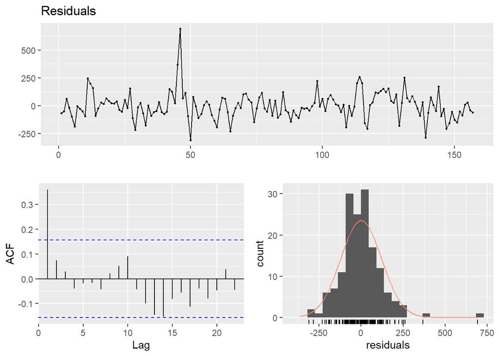

```
##
##  Breusch-Godfrey test for serial correlation of order up to 26
##
## data:  Residuals
## LM test = 50.047, df = 26, p-value = 0.003104
```

```r
checkresiduals(lmodel)
```

```r
test_data[,predicted:=predict(lmodel,test_data)]
for(i in 1:50){
data_ts=ts(kulaklık $sold_count[1:(i+324-2)],frequency = 1)
arima_model=auto.arima(data_ts)
predictions=forecast(arima_model,h=2)
predicted_arima<-as.vector(predictions$mean)
test_data$predicted_arima[i]<-predicted_arima[2]
}
for(i in 1:50){
  xreg = basket=kulaklık$basket[1:(i+324-2)]
  data_ts=ts(kulaklık $sold_count[1:(i+324-2)],frequency = 1)
  arima_model=auto.arima(data_ts,xreg=xreg)
  predictions=forecast(arima_model,h=2,xreg= kulaklık$basket[(i+324-1):(i+324)])
  predicted_arima<-as.vector(predictions$mean)
  test_data$predicted_lr_arima[i]<-predicted_arima[2]
}
```

*Then, we apply linear regression to earphone’s daily sold count. We don’t use first 217 observations of train data to build linear model. Because, value of category visit and value of trendyol visit are missing in the first 217 observations. We try a few more models and select the one having higher R-adjusted value. We use checkresiduals function. P-value is equal to 0.003104. This value is small enough. White noise doesn’t exist.

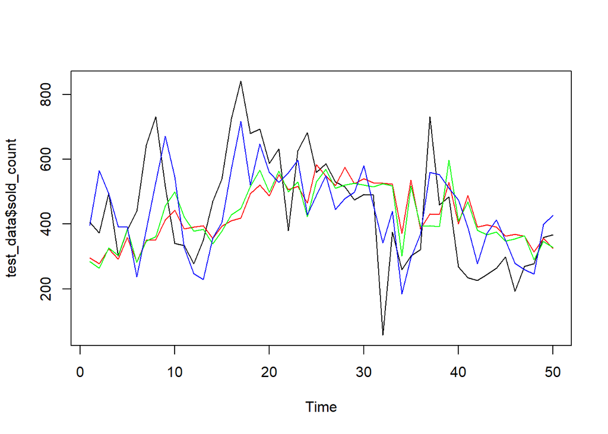

```r
ts.plot(test_data$sold_count)
lines(test_data$predicted_arima,col="red")
lines(test_data$predicted_lr_arima,col="green")
lines(test_data$predicted,col="blue")
```

```r
test_data2<-test_data[1:49]
pred_datatable=test_data2[,.(sold_count,predicted,predicted_arima,predicted_lr_arima)]
melted=melt(pred_datatable,id.vars=c(1))
summary_result=melted[,list(se=(value-sold_count)^2,
                            ad=abs(value-sold_count),
                            ape=abs(value-sold_count)/sold_count,sold_count),by=list(variable)]

summary_result=summary_result[,list(mse=mean(se),mad=mean(ad),mape=mean(ape)),by=list(variable)]
summary_result
```

```
##              variable      mse       mad      mape
## 1:          predicted 15534.22  99.23248 0.3288689
## 2:    predicted_arima 29075.95 133.08592 0.4641433
## 3: predicted_lr_arima 28098.06 128.53640 0.4491961
```

*When we compare their performances, linear regression model has the lowest mape. Therefore, we select this model to predict tomorrow sold count of earphone.

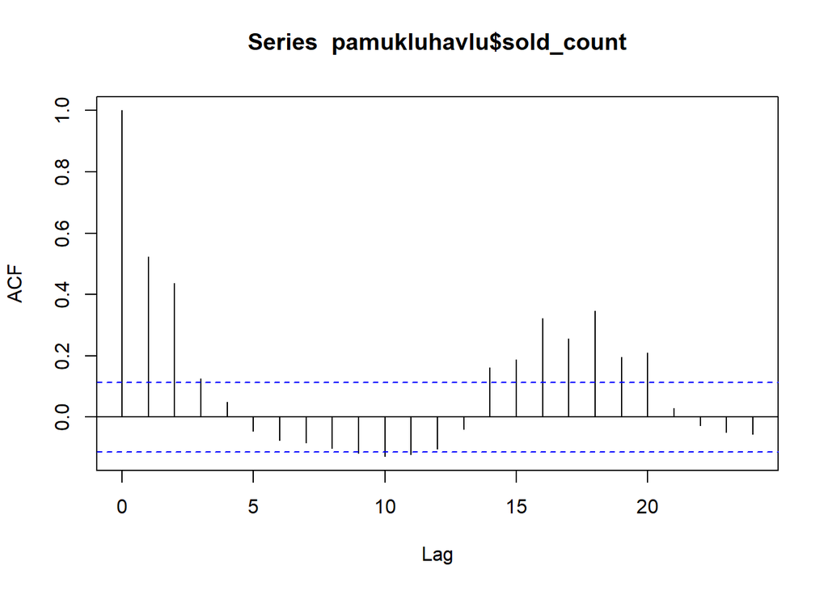

```r
pamukluhavlu$meanthree<-0
for(i in 0:292){
for(j in 0:2){
pamukluhavlu$meanthree[3+i]<-pamukluhavlu$meanthree[3+i]+pamukluhavlu$sold_count[1+i+j]
}
pamukluhavlu$meanthree[3+i]<-pamukluhavlu$meanthree[3+i]/3
}
pamukluhavlu$meanthreetwo[5:295]<-pamukluhavlu$meanthree[3:293]
pamukluhavlu$meanweek<-0
for(i in 0:288){
for(j in 0:6){
pamukluhavlu$meanweek[7+i]<- pamukluhavlu$meanweek[7+i]+pamukluhavlu$sold_count[1+i+j]
}
pamukluhavlu$meanweek[7+i]<- pamukluhavlu$meanweek[7+i]/7
}
pamukluhavlu$meanweektwo[9:295]<- pamukluhavlu$meanweek[7:293]

pamukluhavlu$one[2:295]<- pamukluhavlu$sold_count[1:294]
pamukluhavlu$two[3:295]<- pamukluhavlu$sold_count[1:293]
pamukluhavlu$three[4:295]<- pamukluhavlu$sold_count[1:292]
pamukluhavlu$four[5:295]<- pamukluhavlu$sold_count[1:291]
pamukluhavlu$five[6:295]<- pamukluhavlu$sold_count[1:290]
pamukluhavlu$six[7:295]<- pamukluhavlu$sold_count[1:289]
pamukluhavlu$seven[8:295]<- pamukluhavlu$sold_count[1:288]

pamukluhavlu$visit[3:295]<- pamukluhavlu$visit_count[1:293]
pamukluhavlu$favored[3:295]<- pamukluhavlu$favored_count[1:293]
pamukluhavlu$basket[3:295]<- pamukluhavlu$basket_count[1:293]
pamukluhavlu$category[3:295]<- pamukluhavlu$category_sold[1:293]
pamukluhavlu$category_brand[3:295]<- pamukluhavlu$category_brand_sold[1:293]
pamukluhavlu$category_visit2[3:295]<- pamukluhavlu$category_visits[1:293]
pamukluhavlu$ty[3:295]<- pamukluhavlu$ty_visits[1:293]
pamukluhavlu$pricetwo[3:295]<- pamukluhavlu$price[1:293]
pamukluhavlu$priceone [2:295]<- pamukluhavlu$price[1:294]
pamukluhavlu [,event_date:=as.POSIXct(pamukluhavlu$event_date,format='%Y-%m-%d' ) ]
pamukluhavlu$date<- weekdays(as.Date(pamukluhavlu$event_date))
test_data=tail(pamukluhavlu,50)
data=pamukluhavlu[1:(nrow(pamukluhavlu)-50)]
acf(pamukluhavlu$sold_count)
```

*We try to find seasonality for cotton towel’s data. We use autocorrelation function to find seansonality. But we cannot observe any seasonality.

```r
lmodel=lm(formula=sold_count ~ two,data= pamukluhavlu [139:245])
summary(lmodel)
```

```
##
## Call:
## lm(formula = sold_count ~ two, data = pamukluhavlu[139:245])
##
## Residuals:
##     Min      1Q  Median      3Q     Max
## -225.07  -86.86  -48.82   29.65 1055.11
##
## Coefficients:
##              Estimate Std. Error t value Pr(>|t|)
## (Intercept) 183.95736   29.39332   6.258  8.6e-09 ***
## two           0.23005    0.09442   2.436   0.0165 *
## ---
## Signif. codes:  0 '***' 0.001 '**' 0.01 '*' 0.05 '.' 0.1 ' ' 1
##
## Residual standard error: 197.9 on 105 degrees of freedom
## Multiple R-squared:  0.05351,    Adjusted R-squared:  0.0445
## F-statistic: 5.936 on 1 and 105 DF,  p-value: 0.01652
```

```r
lmodel=lm(formula=sold_count ~ two+visit+favored+basket+category+category_brand+category_visit2+ty,data= pamukluhavlu [139:245])
summary(lmodel)
```

```
##
## Call:
## lm(formula = sold_count ~ two + visit + favored + basket + category +
##     category_brand + category_visit2 + ty, data = pamukluhavlu[139:245])
##
## Residuals:
##     Min      1Q  Median      3Q     Max
## -246.85  -79.28  -40.45   24.64  989.36
##
## Coefficients:
##                   Estimate Std. Error t value Pr(>|t|)
## (Intercept)      2.322e+01  7.450e+01   0.312 0.755984
## two             -1.482e+00  3.404e-01  -4.353  3.3e-05 ***
## visit           -7.256e-02  4.852e-02  -1.495 0.138027
## favored          3.367e+00  1.197e+00   2.813 0.005936 **
## basket           6.385e-01  1.661e-01   3.844 0.000215 ***
## category         2.719e+00  1.178e+00   2.309 0.023050 *
## category_brand  -7.540e+00  3.158e+00  -2.388 0.018866 *
## category_visit2 -2.824e-03  1.627e-03  -1.736 0.085711 .
## ty               4.587e-08  7.844e-07   0.058 0.953483
## ---
## Signif. codes:  0 '***' 0.001 '**' 0.01 '*' 0.05 '.' 0.1 ' ' 1
##
## Residual standard error: 172.9 on 98 degrees of freedom
## Multiple R-squared:  0.3262, Adjusted R-squared:  0.2712
## F-statistic: 5.932 on 8 and 98 DF,  p-value: 3.438e-06
```

```r
lmodel=lm(formula=sold_count ~ as.factor(date)+two+three+four+five+six+seven +visit+favored+basket+category+category_brand+meanweektwo,data)
summary(lmodel)
```

```
##
## Call:
## lm(formula = sold_count ~ as.factor(date) + two + three + four +
##     five + six + seven + visit + favored + basket + category +
##     category_brand + meanweektwo, data = data)
##
## Residuals:
##      Min       1Q   Median       3Q      Max
## -1057.25  -111.84   -46.12    51.06  3076.87
##
## Coefficients:
##                           Estimate Std. Error t value Pr(>|t|)
## (Intercept)               -5.25640   80.41114  -0.065 0.947940
## as.factor(date)Cumartesi  63.62911   83.23948   0.764 0.445449
## as.factor(date)Çarşamba   99.76759   83.27167   1.198 0.232180
## as.factor(date)Pazar     -14.65665   82.85614  -0.177 0.859757
## as.factor(date)Pazartesi  74.68533   83.55463   0.894 0.372388
## as.factor(date)Perşembe   13.34583   82.60905   0.162 0.871807
## as.factor(date)Salı       69.73113   82.75719   0.843 0.400376
## two                       -0.58931    0.16053  -3.671 0.000304 ***
## three                     -0.04030    0.09163  -0.440 0.660548
## four                       0.09555    0.09481   1.008 0.314667
## five                       0.02353    0.08379   0.281 0.779158
## six                       -0.02618    0.10562  -0.248 0.804507
## seven                      0.03865    0.10786   0.358 0.720451
## visit                     -0.03146    0.02594  -1.213 0.226577
## favored                    5.92793    0.74496   7.957 9.52e-14 ***
## basket                    -0.03482    0.06063  -0.574 0.566397
## category                   0.06116    0.94112   0.065 0.948247
## category_brand            -0.71198    2.63878  -0.270 0.787559
## meanweektwo               -0.25607    0.42715  -0.599 0.549473
## ---
## Signif. codes:  0 '***' 0.001 '**' 0.01 '*' 0.05 '.' 0.1 ' ' 1
##
## Residual standard error: 335 on 218 degrees of freedom
##   (8 observations deleted due to missingness)
## Multiple R-squared:  0.4869, Adjusted R-squared:  0.4446
## F-statistic: 11.49 on 18 and 218 DF,  p-value: < 2.2e-16
```

```r
lmodel=lm(formula=sold_count ~ as.factor(date)+two+three+four+five+six+seven +visit+favored+basket+category+category_brand+category_visit2+ty+meanweektwo,data= pamukluhavlu [139:245])
summary(lmodel)
```

```
##
## Call:
## lm(formula = sold_count ~ as.factor(date) + two + three + four +
##     five + six + seven + visit + favored + basket + category +
##     category_brand + category_visit2 + ty + meanweektwo, data = pamukluhavlu[139:245])
##
## Residuals:
##     Min      1Q  Median      3Q     Max
## -254.13  -71.82  -15.63   39.39  905.02
##
## Coefficients:
##                            Estimate Std. Error t value Pr(>|t|)
## (Intercept)              -1.752e+01  9.066e+01  -0.193  0.84723
## as.factor(date)Cumartesi  1.336e+01  7.092e+01   0.188  0.85101
## as.factor(date)Çarşamba   1.674e+02  7.641e+01   2.191  0.03114 *
## as.factor(date)Pazar      1.550e+00  7.478e+01   0.021  0.98351
## as.factor(date)Pazartesi  1.618e+01  7.364e+01   0.220  0.82664
## as.factor(date)Perşembe   1.862e+01  6.832e+01   0.273  0.78584
## as.factor(date)Salı       1.243e+02  7.309e+01   1.701  0.09257 .
## two                      -1.134e+00  4.000e-01  -2.834  0.00572 **
## three                    -1.320e-01  2.212e-01  -0.597  0.55226
## four                     -4.731e-02  2.053e-01  -0.230  0.81836
## five                      1.527e-01  1.973e-01   0.774  0.44113
## six                      -5.294e-02  1.960e-01  -0.270  0.78771
## seven                    -3.611e-03  2.651e-01  -0.014  0.98916
## visit                    -4.070e-02  5.273e-02  -0.772  0.44226
## favored                   2.439e+00  1.403e+00   1.738  0.08581 .
## basket                    5.261e-01  1.763e-01   2.984  0.00370 **
## category                  1.889e+00  1.306e+00   1.446  0.15187
## category_brand           -5.181e+00  3.494e+00  -1.483  0.14176
## category_visit2          -1.999e-03  1.778e-03  -1.124  0.26414
## ty                        1.345e-07  8.386e-07   0.160  0.87294
## meanweektwo               4.590e-02  9.044e-01   0.051  0.95963
## ---
## Signif. codes:  0 '***' 0.001 '**' 0.01 '*' 0.05 '.' 0.1 ' ' 1
##
## Residual standard error: 170.1 on 86 degrees of freedom
## Multiple R-squared:  0.4276, Adjusted R-squared:  0.2945
## F-statistic: 3.212 on 20 and 86 DF,  p-value: 9.093e-05
```

```r
lmodel=lm(formula=sold_count ~ as.factor(date)+two+three+four+five+six+seven +visit+favored+basket+category+category_brand+category_visit2+ty+meanweektwo +pricetwo,data= pamukluhavlu [139:245])
summary(lmodel)
```

```
##
## Call:
## lm(formula = sold_count ~ as.factor(date) + two + three + four +
##     five + six + seven + visit + favored + basket + category +
##     category_brand + category_visit2 + ty + meanweektwo + pricetwo,
##     data = pamukluhavlu[139:245])
##
## Residuals:
##     Min      1Q  Median      3Q     Max
## -264.70  -80.98  -21.36   50.61  856.89
##
## Coefficients:
##                            Estimate Std. Error t value Pr(>|t|)
## (Intercept)               7.502e+02  4.474e+02   1.677  0.09730 .
## as.factor(date)Cumartesi  1.529e-01  7.049e+01   0.002  0.99827
## as.factor(date)Çarşamba   1.576e+02  7.571e+01   2.081  0.04041 *
## as.factor(date)Pazar     -1.401e+01  7.443e+01  -0.188  0.85118
## as.factor(date)Pazartesi -4.592e+00  7.373e+01  -0.062  0.95048
## as.factor(date)Perşembe   1.100e+01  6.766e+01   0.163  0.87123
## as.factor(date)Salı       9.749e+01  7.384e+01   1.320  0.19029
## two                      -1.184e+00  3.964e-01  -2.988  0.00367 **
## three                    -1.571e-01  2.191e-01  -0.717  0.47540
## four                     -5.432e-02  2.030e-01  -0.268  0.78963
## five                      1.514e-01  1.950e-01   0.776  0.43971
## six                      -3.307e-02  1.940e-01  -0.170  0.86502
## seven                    -2.448e-02  2.623e-01  -0.093  0.92584
## visit                    -5.194e-02  5.250e-02  -0.989  0.32527
## favored                   3.145e+00  1.444e+00   2.177  0.03222 *
## basket                    4.351e-01  1.818e-01   2.393  0.01893 *
## category                  2.646e+00  1.361e+00   1.943  0.05527 .
## category_brand           -7.151e+00  3.631e+00  -1.969  0.05219 .
## category_visit2          -1.953e-03  1.757e-03  -1.111  0.26952
## ty                        1.051e-06  9.803e-07   1.073  0.28649
## meanweektwo               2.574e-02  8.938e-01   0.029  0.97709
## pricetwo                 -1.275e+01  7.280e+00  -1.751  0.08353 .
## ---
## Signif. codes:  0 '***' 0.001 '**' 0.01 '*' 0.05 '.' 0.1 ' ' 1
##
## Residual standard error: 168.1 on 85 degrees of freedom
## Multiple R-squared:  0.4475, Adjusted R-squared:  0.311
## F-statistic: 3.278 on 21 and 85 DF,  p-value: 5.631e-05
```

```r
lmodel=lm(formula=sold_count ~ as.factor(date)+two+visit+favored+basket+meanweektwo +pricetwo,data= pamukluhavlu [139:245])
summary(lmodel)
```

```
##
## Call:
## lm(formula = sold_count ~ as.factor(date) + two + visit + favored +
##     basket + meanweektwo + pricetwo, data = pamukluhavlu[139:245])
##
## Residuals:
##     Min      1Q  Median      3Q     Max
## -255.56  -74.97  -17.35   67.26  881.47
##
## Coefficients:
##                           Estimate Std. Error t value Pr(>|t|)
## (Intercept)              173.26337  330.21299   0.525  0.60103
## as.factor(date)Cumartesi  -7.70878   63.48110  -0.121  0.90361
## as.factor(date)Çarşamba  198.93623   68.52385   2.903  0.00460 **
## as.factor(date)Pazar       6.69346   66.60257   0.100  0.92016
## as.factor(date)Pazartesi  48.70410   67.44314   0.722  0.47199
## as.factor(date)Perşembe   41.14592   64.60231   0.637  0.52573
## as.factor(date)Salı      128.96593   68.76957   1.875  0.06385 .
## two                       -1.05699    0.31317  -3.375  0.00107 **
## visit                     -0.03612    0.05022  -0.719  0.47376
## favored                    2.39157    1.23050   1.944  0.05494 .
## basket                     0.41509    0.17158   2.419  0.01748 *
## meanweektwo                0.05116    0.16543   0.309  0.75780
## pricetwo                  -1.53358    4.84827  -0.316  0.75247
## ---
## Signif. codes:  0 '***' 0.001 '**' 0.01 '*' 0.05 '.' 0.1 ' ' 1
##
## Residual standard error: 167.8 on 94 degrees of freedom
## Multiple R-squared:  0.3909, Adjusted R-squared:  0.3131
## F-statistic: 5.027 on 12 and 94 DF,  p-value: 2.136e-06
```

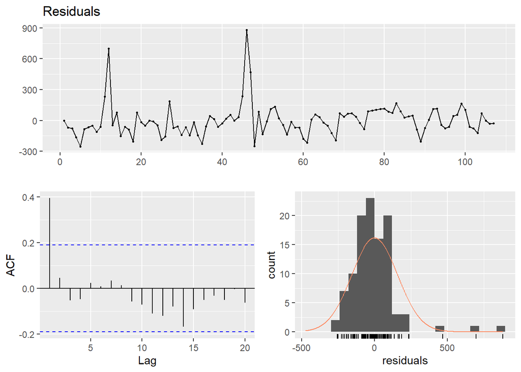

```
##
##  Breusch-Godfrey test for serial correlation of order up to 16
##
## data:  Residuals
## LM test = 32.799, df = 16, p-value = 0.007857
```

```r
checkresiduals(lmodel)
```

```r
test_data[,predicted:=predict(lmodel,test_data)]
for(i in 1:50){
data_ts=ts(pamukluhavlu$sold_count[1:(i+245-2)],frequency =1)
arima_model=auto.arima(data_ts)
predictions=forecast(arima_model,h=2)
predicted_arima<-as.vector(predictions$mean)
test_data$predicted_arima[i]<-predicted_arima[2]
}
for(i in 1:50){
data_ts=ts(pamukluhavlu$sold_count[139:(i+245-2)],frequency = 1)
arima_model=auto.arima(data_ts,xreg=pamukluhavlu$basket[139:(i+245-2)])
predictions=forecast(arima_model,h=2,xreg= pamukluhavlu$basket [(i+245-1):(i+245)])
predicted_arima<-as.vector(predictions$mean)
test_data$predicted_lr_arima[i]<-predicted_arima[2]
}
```

*We apply linear regression to cotton towel’ daily sold count. We don’t use first 138 observations of train data to build linear model. Because, value of category visit and value of trendyol visit are missing in the first 138 observations. We try a few more models and select the one having the lowest mape value. We use checkresiduals function. P-value is equal to 0.007857. This value is small enough. White noise doesn’t exist.

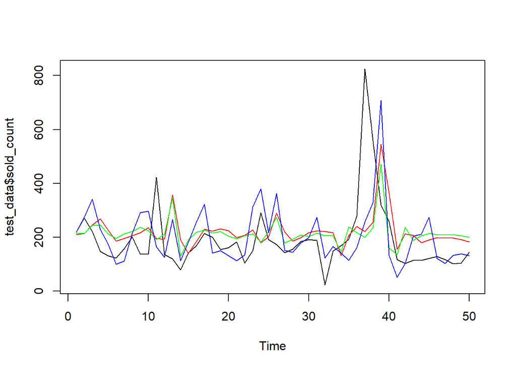

```r
ts.plot(test_data$sold_count)
lines(test_data$predicted_arima,col="red")
lines(test_data$predicted_lr_arima,col="green")
lines(test_data$predicted,col="blue")
```

```r
Ma3<-pamukluhavlu$meanthreetwo[246:295]
pred_datatable=test_data[,.(sold_count,predicted,predicted_arima,predicted_lr_arima,Ma3)]
melted=melt(pred_datatable,id.vars=c(1))
summary_result=melted[,list(se=(value-sold_count)^2,
                            ad=abs(value-sold_count),
                            ape=abs(value-sold_count)/sold_count,sold_count),by=list(variable)]

summary_result=summary_result[,list(mse=mean(se),mad=mean(ad),mape=mean(ape)),by=list(variable)]
summary_result
```

```
##              variable      mse      mad      mape
## 1:          predicted 17836.77 85.11398 0.4985553
## 2:    predicted_arima 17193.84 87.46650 0.6363031
## 3: predicted_lr_arima 17245.45 87.61828 0.6222025
## 4:                Ma3 24180.40 95.08000 0.6297794
```

*When we compare their performances, linear regression model has the lowest mape. Therefore, we select this model to predict tomorrow sold count of cotton towel.

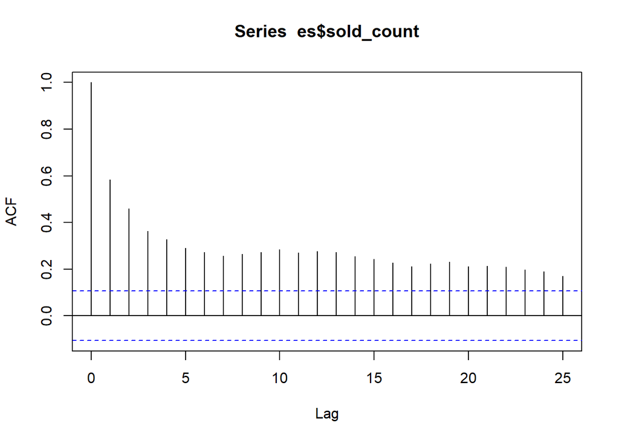

```r
es$meanthree<-0
for(i in 0:336){
for(j in 0:2){
es$meanthree[3+i]<-es$meanthree[3+i]+es$sold_count[1+i+j]
}
es$meanthree[3+i]<-es$meanthree[3+i]/3
}
es$meanthreetwo[5:339]<-es$meanthree[3:337]
es$meanweek<-0
for(i in 0:332){
for(j in 0:6){
es$meanweek[7+i]<- es$meanweek[7+i]+es$sold_count[1+i+j]
}
es$meanweek[7+i]<- es$meanweek[7+i]/7
}
es$meanweektwo[9:339]<- es$meanweek[7:337]

es$one[2:339]<- es$sold_count[1:338]
es$two[3:339]<- es$sold_count[1:337]
es$three[4:339]<- es$sold_count[1:336]
es$four[5:339]<- es$sold_count[1:335]
es$five[6:339]<- es$sold_count[1:334]
es$six[7:339]<- es$sold_count[1:333]
es$seven[8:339]<- es$sold_count[1:332]

es$visit[3:339]<- es$visit_count[1:337]
es$favored[3:339]<- es$favored_count[1:337]
es$basket[3:339]<- es$basket_count[1:337]
es$category[3:339]<- es$category_sold[1:337]
es$category_brand[3:339]<- es$category_brand_sold[1:337]
es$category_visit2[3:339]<- es$category_visits[1:337]
es$ty[3:339]<- es$ty_visits[1:337]
es$pricetwo[3:339]<- es$price[1:337]
es$priceone [2:339]<- es$price[1:338]
es [,event_date:=as.POSIXct(es$event_date,format='%Y-%m-%d' ) ]
es$date<- weekdays(as.Date(es$event_date))
test_data=tail(es,50)
data=es[1:(nrow(es)-50)]
acf(es$sold_count)
```

*We try to find seasonality for vacuum cleaner’s data. We use autocorrelation function to find seansonality. But we cannot observe any seasonality.

```r
lmodel=lm(formula=sold_count ~ two,data= es[183:289])
summary(lmodel)
```

```
##
## Call:
## lm(formula = sold_count ~ two, data = es[183:289])
##
## Residuals:
##     Min      1Q  Median      3Q     Max
## -90.356 -15.593  -5.068  12.902  93.712
##
## Coefficients:
##             Estimate Std. Error t value Pr(>|t|)
## (Intercept) 21.57544    5.20597   4.144 6.92e-05 ***
## two          0.60488    0.07848   7.707 7.62e-12 ***
## ---
## Signif. codes:  0 '***' 0.001 '**' 0.01 '*' 0.05 '.' 0.1 ' ' 1
##
## Residual standard error: 29.87 on 105 degrees of freedom
## Multiple R-squared:  0.3613, Adjusted R-squared:  0.3552
## F-statistic:  59.4 on 1 and 105 DF,  p-value: 7.619e-12
```

```r
lmodel=lm(formula=sold_count ~ two+visit+favored+basket+category+category_brand+category_visit2+ty,data= es[183:289])
summary(lmodel)
```

```
##
## Call:
## lm(formula = sold_count ~ two + visit + favored + basket + category +
##     category_brand + category_visit2 + ty, data = es[183:289])
##
## Residuals:
##     Min      1Q  Median      3Q     Max
## -66.556 -13.262  -3.682  11.102  94.061
##
## Coefficients:
##                   Estimate Std. Error t value Pr(>|t|)
## (Intercept)      3.843e+01  1.603e+01   2.398   0.0184 *
## two             -3.776e-02  2.188e-01  -0.173   0.8634
## visit           -4.153e-03  6.020e-03  -0.690   0.4919
## favored          1.312e-01  8.725e-02   1.504   0.1358
## basket           4.465e-02  8.835e-02   0.505   0.6145
## category        -4.200e-01  1.771e-01  -2.372   0.0197 *
## category_brand   1.076e+00  5.129e-01   2.097   0.0385 *
## category_visit2  8.525e-05  8.981e-05   0.949   0.3448
## ty               3.782e-07  1.521e-07   2.486   0.0146 *
## ---
## Signif. codes:  0 '***' 0.001 '**' 0.01 '*' 0.05 '.' 0.1 ' ' 1
##
## Residual standard error: 24.89 on 98 degrees of freedom
## Multiple R-squared:  0.5861, Adjusted R-squared:  0.5523
## F-statistic: 17.35 on 8 and 98 DF,  p-value: 7.827e-16
```

```r
lmodel=lm(formula=sold_count ~ as.factor(date)+two+three+four+five+six+seven +visit+favored+basket+category+category_brand+meanweektwo,data)
summary(lmodel)
```

```
##
## Call:
## lm(formula = sold_count ~ as.factor(date) + two + three + four +
##     five + six + seven + visit + favored + basket + category +
##     category_brand + meanweektwo, data = data)
##
## Residuals:
##    Min     1Q Median     3Q    Max
## -67.84 -12.78  -5.30   7.24 414.79
##
## Coefficients:
##                           Estimate Std. Error t value Pr(>|t|)
## (Intercept)              20.747606   7.746878   2.678  0.00787 **
## as.factor(date)Cumartesi 11.753999   7.408648   1.587  0.11383
## as.factor(date)Çarşamba   8.777732   7.387572   1.188  0.23584
## as.factor(date)Pazar      5.446672   7.404893   0.736  0.46266
## as.factor(date)Pazartesi  4.405531   7.467138   0.590  0.55571
## as.factor(date)Perşembe   5.667957   7.396443   0.766  0.44418
## as.factor(date)Salı       8.465622   7.391368   1.145  0.25311
## two                      -0.264401   0.185006  -1.429  0.15415
## three                    -0.051210   0.097489  -0.525  0.59982
## four                      0.020066   0.097137   0.207  0.83651
## five                     -0.019612   0.093445  -0.210  0.83392
## six                      -0.022814   0.096431  -0.237  0.81317
## seven                    -0.057153   0.106048  -0.539  0.59039
## visit                     0.001626   0.005026   0.324  0.74654
## favored                   0.052744   0.081373   0.648  0.51744
## basket                    0.139709   0.023967   5.829 1.63e-08 ***
## category                 -0.153096   0.072759  -2.104  0.03632 *
## category_brand            0.294450   0.215309   1.368  0.17262
## meanweektwo               0.427388   0.446169   0.958  0.33899
## ---
## Signif. codes:  0 '***' 0.001 '**' 0.01 '*' 0.05 '.' 0.1 ' ' 1
##
## Residual standard error: 32.74 on 262 degrees of freedom
##   (8 observations deleted due to missingness)
## Multiple R-squared:  0.3903, Adjusted R-squared:  0.3485
## F-statistic: 9.319 on 18 and 262 DF,  p-value: < 2.2e-16
```

```r
lmodel=lm(formula=sold_count ~ as.factor(date)+two+three+four+five+six+seven +visit+favored+basket+category+category_brand+category_visit2+ty+meanweektwo,data= es[183:289])
summary(lmodel)
```

```
##
## Call:
## lm(formula = sold_count ~ as.factor(date) + two + three + four +
##     five + six + seven + visit + favored + basket + category +
##     category_brand + category_visit2 + ty + meanweektwo, data = es[183:289])
##
## Residuals:
##     Min      1Q  Median      3Q     Max
## -47.111 -14.532  -1.246   7.956  81.894
##
## Coefficients:
##                            Estimate Std. Error t value Pr(>|t|)
## (Intercept)               9.434e+00  1.795e+01   0.525  0.60061
## as.factor(date)Cumartesi  7.007e+00  9.105e+00   0.770  0.44365
## as.factor(date)Çarşamba   2.900e+01  9.406e+00   3.084  0.00275 **
## as.factor(date)Pazar      1.688e+01  9.782e+00   1.726  0.08800 .
## as.factor(date)Pazartesi  1.973e+01  9.730e+00   2.028  0.04566 *
## as.factor(date)Perşembe   1.693e+01  9.179e+00   1.844  0.06859 .
## as.factor(date)Salı       2.366e+01  9.772e+00   2.422  0.01755 *
## two                      -1.506e-01  2.755e-01  -0.547  0.58603
## three                    -3.154e-01  2.243e-01  -1.406  0.16336
## four                      5.688e-02  2.380e-01   0.239  0.81171
## five                      2.910e-02  2.239e-01   0.130  0.89689
## six                      -3.205e-01  2.135e-01  -1.501  0.13692
## seven                    -3.216e-01  2.870e-01  -1.121  0.26550
## visit                    -4.968e-03  6.152e-03  -0.808  0.42154
## favored                   1.529e-01  9.005e-02   1.698  0.09304 .
## basket                    6.780e-02  9.095e-02   0.746  0.45798
## category                 -2.575e-01  1.795e-01  -1.435  0.15501
## category_brand            6.020e-01  5.203e-01   1.157  0.25041
## category_visit2           2.183e-05  9.723e-05   0.225  0.82288
## ty                        3.910e-07  1.618e-07   2.416  0.01781 *
## meanweektwo               1.033e+00  9.901e-01   1.043  0.29987
## ---
## Signif. codes:  0 '***' 0.001 '**' 0.01 '*' 0.05 '.' 0.1 ' ' 1
##
## Residual standard error: 24.21 on 86 degrees of freedom
## Multiple R-squared:  0.6562, Adjusted R-squared:  0.5762
## F-statistic: 8.206 on 20 and 86 DF,  p-value: 1.073e-12
```

```r
lmodel=lm(formula=sold_count ~ as.factor(date)+two+three+four+five+six+seven +visit+favored+basket+category+category_brand+category_visit2+ty+meanweektwo +pricetwo,data= es[183:289])
summary(lmodel)
```

```
##
## Call:
## lm(formula = sold_count ~ as.factor(date) + two + three + four +
##     five + six + seven + visit + favored + basket + category +
##     category_brand + category_visit2 + ty + meanweektwo + pricetwo,
##     data = es[183:289])
##
## Residuals:
##     Min      1Q  Median      3Q     Max
## -41.419 -13.335  -1.305   9.480  80.447
##
## Coefficients:
##                            Estimate Std. Error t value Pr(>|t|)
## (Intercept)               7.639e+01  7.859e+01   0.972  0.33383
## as.factor(date)Cumartesi  6.050e+00  9.182e+00   0.659  0.51172
## as.factor(date)Çarşamba   2.856e+01  9.432e+00   3.029  0.00325 **
## as.factor(date)Pazar      1.610e+01  9.836e+00   1.637  0.10538
## as.factor(date)Pazartesi  1.800e+01  9.942e+00   1.811  0.07370 .
## as.factor(date)Perşembe   1.575e+01  9.291e+00   1.695  0.09376 .
## as.factor(date)Salı       2.217e+01  9.933e+00   2.232  0.02825 *
## two                      -1.512e-01  2.759e-01  -0.548  0.58497
## three                    -2.954e-01  2.258e-01  -1.308  0.19431
## four                      6.084e-02  2.384e-01   0.255  0.79919
## five                      6.009e-02  2.270e-01   0.265  0.79184
## six                      -3.116e-01  2.140e-01  -1.456  0.14906
## seven                    -3.072e-01  2.878e-01  -1.067  0.28881
## visit                    -3.998e-03  6.260e-03  -0.639  0.52478
## favored                   1.577e-01  9.034e-02   1.746  0.08450 .
## basket                    4.014e-02  9.640e-02   0.416  0.67817
## category                 -3.157e-01  1.916e-01  -1.647  0.10320
## category_brand            7.870e-01  5.622e-01   1.400  0.16521
## category_visit2           3.456e-05  9.844e-05   0.351  0.72642
## ty                        4.655e-07  1.830e-07   2.543  0.01281 *
## meanweektwo               9.206e-01  9.997e-01   0.921  0.35971
## pricetwo                 -3.002e-01  3.431e-01  -0.875  0.38398
## ---
## Signif. codes:  0 '***' 0.001 '**' 0.01 '*' 0.05 '.' 0.1 ' ' 1
##
## Residual standard error: 24.25 on 85 degrees of freedom
## Multiple R-squared:  0.6592, Adjusted R-squared:  0.575
## F-statistic:  7.83 on 21 and 85 DF,  p-value: 2.243e-12
```

```r
lmodel=lm(formula=sold_count ~ as.factor(date)+two+visit+favored+basket+meanweektwo +pricetwo,data= es[183:289])
summary(lmodel)
```

```
##
## Call:
## lm(formula = sold_count ~ as.factor(date) + two + visit + favored +
##     basket + meanweektwo + pricetwo, data = es[183:289])
##
## Residuals:
##     Min      1Q  Median      3Q     Max
## -65.779 -13.857  -2.475  14.198  79.997
##
## Coefficients:
##                            Estimate Std. Error t value Pr(>|t|)
## (Intercept)              -40.693502  59.867829  -0.680   0.4984
## as.factor(date)Cumartesi   0.768202  10.109014   0.076   0.9396
## as.factor(date)Çarşamba   22.460191  10.245770   2.192   0.0308 *
## as.factor(date)Pazar      12.904298  10.461464   1.234   0.2205
## as.factor(date)Pazartesi  22.515202  10.500558   2.144   0.0346 *
## as.factor(date)Perşembe   16.666744  10.253377   1.625   0.1074
## as.factor(date)Salı       22.271707  10.451608   2.131   0.0357 *
## two                        0.056123   0.245383   0.229   0.8196
## visit                     -0.009172   0.006332  -1.448   0.1508
## favored                    0.199877   0.088656   2.255   0.0265 *
## basket                     0.118556   0.087224   1.359   0.1773
## meanweektwo                0.178812   0.161288   1.109   0.2704
## pricetwo                   0.209439   0.277800   0.754   0.4528
## ---
## Signif. codes:  0 '***' 0.001 '**' 0.01 '*' 0.05 '.' 0.1 ' ' 1
##
## Residual standard error: 27.81 on 94 degrees of freedom
## Multiple R-squared:  0.5044, Adjusted R-squared:  0.4411
## F-statistic: 7.971 on 12 and 94 DF,  p-value: 4.439e-10
```

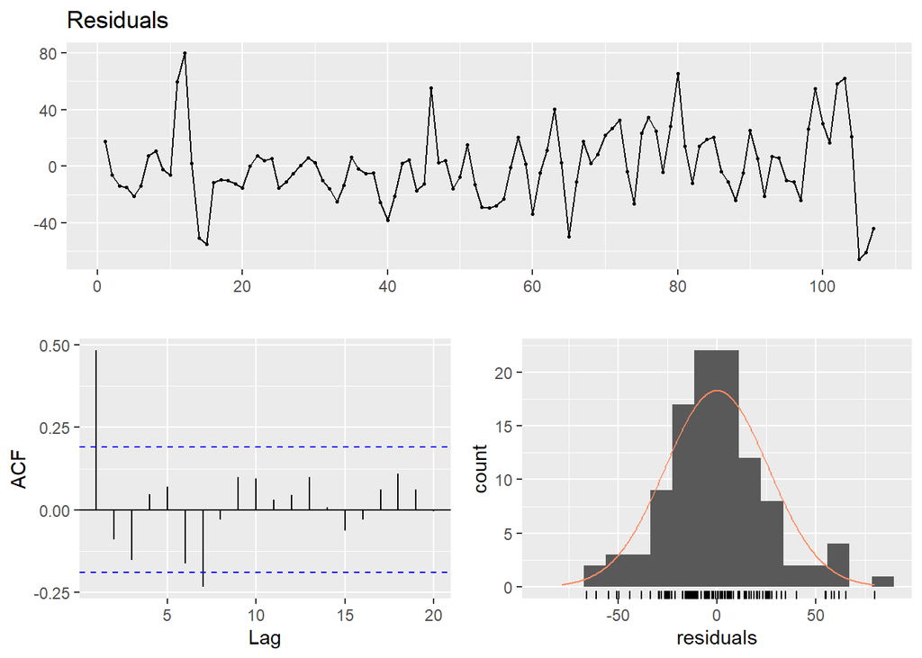

```
##
##  Breusch-Godfrey test for serial correlation of order up to 16
##
## data:  Residuals
## LM test = 52.562, df = 16, p-value = 8.884e-06
```

```r
checkresiduals(lmodel)
```

```r
test_data[,predicted:=predict(lmodel,test_data)]
for(i in 1:50){
data_ts=ts(es$sold_count[1:(i+289-2)],frequency =1)
arima_model=auto.arima(data_ts)
predictions=forecast(arima_model,h=2)
predicted_arima<-as.vector(predictions$mean)
test_data$predicted_arima[i]<-predicted_arima[2]
}
for(i in 1:50){
data_ts=ts(es$sold_count[183:(i+289-2)],frequency = 1)
arima_model=auto.arima(data_ts,xreg=cbind(es$basket[183:(i+289-2)], es$two [183:(i+289-2)]))
predictions=forecast(arima_model,h=2,xreg=cbind(es$basket [(i+289-1):(i+289)],es$two[(i+289-1):(i+289)]))
predicted_arima<-as.vector(predictions$mean)
test_data$predicted_lr_arima[i]<-predicted_arima[2]
}
```

*We apply linear regression to vacuum cleaner’s daily sold count. We don’t use first 182 observations of train data to build linear model. Because, value of category visit and value of trendyol visit are missing in the first 182 observations. We try a few more models and select the one having the lowest mape value. We use checkresiduals function. P-value is equal to 0,00000884. This value is small enough. White noise doesn’t exist.

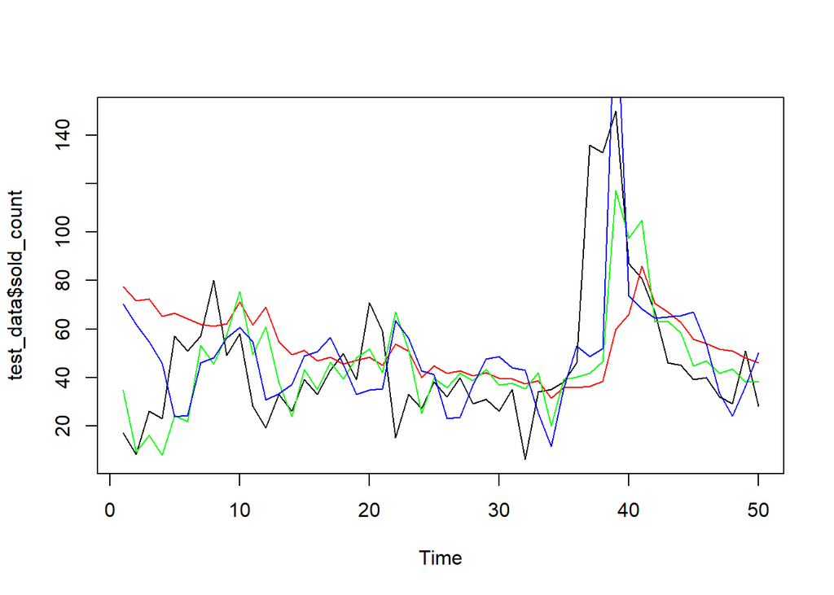

```r
ts.plot(test_data$sold_count)
lines(test_data$predicted_arima,col="red")
lines(test_data$predicted_lr_arima,col="green")
lines(test_data$predicted,col="blue")
```

```r
Ma3<-es$meanthreetwo[290:339]
pred_datatable=test_data[,.(sold_count,predicted,predicted_arima,predicted_lr_arima,Ma3)]
melted=melt(pred_datatable,id.vars=c(1))
summary_result=melted[,list(se=(value-sold_count)^2,
                            ad=abs(value-sold_count),
                            ape=abs(value-sold_count)/sold_count,sold_count),by=list(variable)]

summary_result=summary_result[,list(mse=mean(se),mad=mean(ad),mape=mean(ape)),by=list(variable)]
summary_result
```

```
##              variable       mse      mad      mape
## 1:          predicted  804.1711 21.21544 0.7571494
## 2:    predicted_arima 1041.3598 22.43921 0.8175818
## 3: predicted_lr_arima  624.9991 16.47880 0.4901821
## 4:                Ma3 1055.9267 23.42000 0.6162150
```

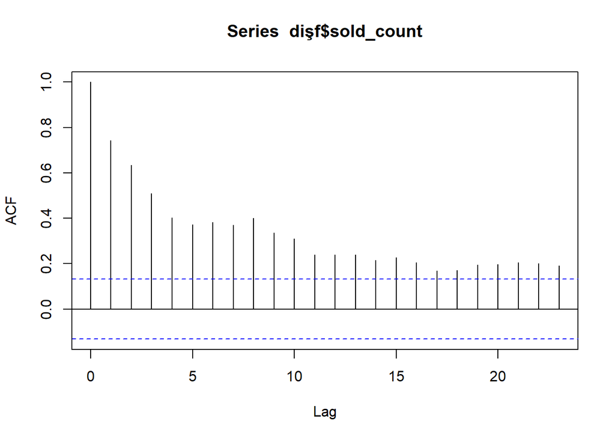

```r
dişf$meanthree<-0
for(i in 0:217){
for(j in 0:2){
dişf$meanthree[3+i]<-dişf$meanthree[3+i]+dişf$sold_count[1+i+j]
}
dişf$meanthree[3+i]<-dişf$meanthree[3+i]/3
}
dişf$meanthreetwo[5:220]<-dişf$meanthree[3:218]
dişf$meanweek<-0
for(i in 0:213){
for(j in 0:6){
dişf$meanweek[7+i]<- dişf$meanweek[7+i]+dişf$sold_count[1+i+j]
}
dişf$meanweek[7+i]<- dişf$meanweek[7+i]/7
}
dişf$meanweektwo[9:220]<- dişf$meanweek[7:218]

dişf$one[2:220]<- dişf$sold_count[1:219]
dişf$two[3:220]<- dişf$sold_count[1:218]
dişf$three[4:220]<- dişf$sold_count[1:217]
dişf$four[5:220]<- dişf$sold_count[1:216]
dişf$five[6:220]<- dişf$sold_count[1:215]
dişf$six[7:220]<- dişf$sold_count[1:214]
dişf$seven[8:220]<- dişf$sold_count[1:213]

dişf$visit[3:220]<- dişf$visit_count[1:218]
dişf$favored[3:220]<- dişf$favored_count[1:218]
dişf$basket[3:220]<- dişf$basket_count[1:218]
dişf$category[3:220]<- dişf$category_sold[1:218]
dişf$category_brand[3:220]<- dişf$category_brand_sold[1:218]
dişf$category_visit2[3:220]<- dişf$category_visits[1:218]
dişf$ty[3:220]<- dişf$ty_visits[1:218]
dişf$pricetwo[3:220]<- dişf$price[1:218]
dişf$priceone [2:220]<- dişf$price[1:219]
dişf[,event_date:=as.POSIXct(dişf$event_date,format='%Y-%m-%d' ) ]
dişf$date<- weekdays(as.Date(dişf$event_date))
test_data=tail(dişf,50)
data=dişf[1:(nrow(dişf)-50)]
acf(dişf$sold_count)
```

*We try to find seasonality for toothbrush’s data. We use autocorrelation function to find seansonality. But we cannot observe any seasonality.

```r
lmodel=lm(formula=sold_count~as.factor(date)+two+three+four+five+six+seven+visit+favored+basket+meanweektwo,data= data[64:220])
summary(lmodel)
```

```
##
## Call:
## lm(formula = sold_count ~ as.factor(date) + two + three + four +
##     five + six + seven + visit + favored + basket + meanweektwo,
##     data = data[64:220])
##
## Residuals:
##     Min      1Q  Median      3Q     Max
## -118.83  -50.53  -12.45   30.86  623.90
##
## Coefficients:
##                            Estimate Std. Error t value Pr(>|t|)
## (Intercept)               44.216492  33.724409   1.311   0.1932
## as.factor(date)Cumartesi -37.347077  38.034118  -0.982   0.3288
## as.factor(date)Çarşamba   47.479642  39.554312   1.200   0.2331
## as.factor(date)Pazar     -23.975964  40.909231  -0.586   0.5593
## as.factor(date)Pazartesi  21.802331  41.432651   0.526   0.6000
## as.factor(date)Perşembe   12.009579  39.045053   0.308   0.7591
## as.factor(date)Salı       79.830415  40.883745   1.953   0.0540 .
## two                        0.847830   0.374530   2.264   0.0260 *
## three                     -0.092168   0.176856  -0.521   0.6035
## four                      -0.298856   0.168871  -1.770   0.0802 .
## five                      -0.308373   0.181506  -1.699   0.0928 .
## six                       -0.149629   0.199235  -0.751   0.4546
## seven                     -0.264301   0.212091  -1.246   0.2159
## visit                     -0.004039   0.013084  -0.309   0.7583
## favored                    0.106943   0.149440   0.716   0.4761
## basket                    -0.110533   0.078180  -1.414   0.1609
## meanweektwo                1.263802   0.826852   1.528   0.1299
## ---
## Signif. codes:  0 '***' 0.001 '**' 0.01 '*' 0.05 '.' 0.1 ' ' 1
##
## Residual standard error: 102 on 90 degrees of freedom
##   (50 observations deleted due to missingness)
## Multiple R-squared:  0.3781, Adjusted R-squared:  0.2676
## F-statistic:  3.42 on 16 and 90 DF,  p-value: 0.0001012
```

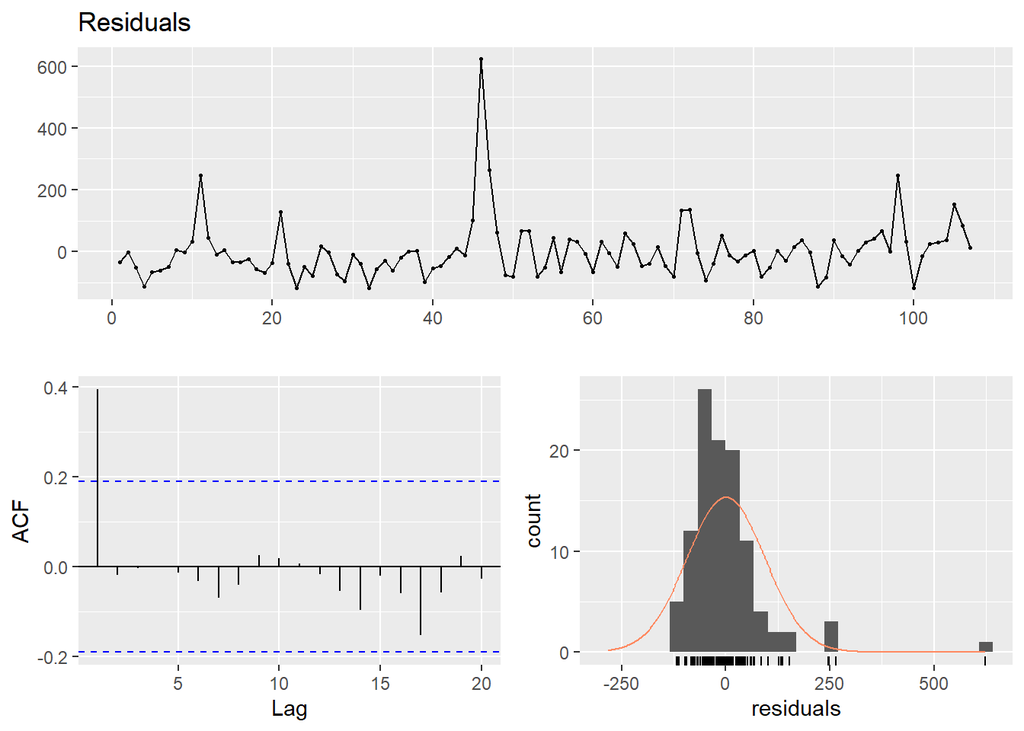

```
##
##  Breusch-Godfrey test for serial correlation of order up to 20
##
## data:  Residuals
## LM test = 32.171, df = 20, p-value = 0.04151
```

```r
checkresiduals(lmodel)
```

```r
test_data[,predicted:=predict(lmodel,test_data)]
for(i in 1:50){
data_ts=ts(dişf$sold_count[1:(i+170-2)],frequency =1)
arima_model=auto.arima(data_ts)
predictions=forecast(arima_model,h=2)
predicted_arima<-as.vector(predictions$mean)
test_data$predicted_arima[i]<-predicted_arima[2]
}
for(i in 1:50){
data_ts=ts(dişf$sold_count[64:(i+170-2)],frequency = 1)
arima_model=auto.arima(data_ts,xreg=cbind(dişf$basket[64:(i+170-2)], dişf$two [64:(i+170-2)]))
predictions=forecast(arima_model,h=2,xreg=cbind(dişf$basket [(i+170-1):(i+170)],dişf$two[(i+170-1):(i+170)]))
predicted_arima<-as.vector(predictions$mean)
test_data$predicted_lr_arima[i]<-predicted_arima[2]
}
```

*We apply linear regression toothbrush’s daily sold count. We don’t use first 63 observations of train data to build linear model. Because, value of category visit and value of trendyol visit are missing in the first 63 observations. We try a few more models and select the one having the lowest mape value. We use checkresiduals function. P-value is equal to 0.04151. This value is small enough. White noise doesn’t exist.

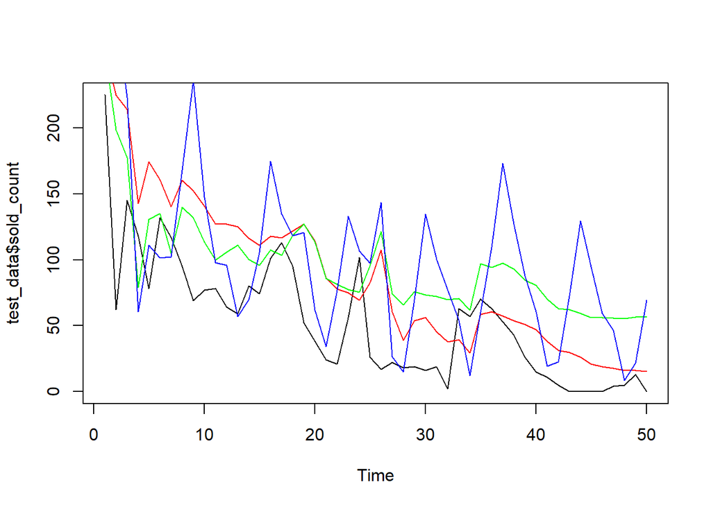

```r
ts.plot(test_data$sold_count)
lines(test_data$predicted_arima,col="red")
lines(test_data$predicted_lr_arima,col="green")
lines(test_data$predicted,col="blue")
```

```r
Ma3<-dişf$meanthreetwo[171:220]
pred_datatable=test_data[,.(sold_count,predicted,predicted_arima,predicted_lr_arima,Ma3)]
melted=melt(pred_datatable,id.vars=c(1))
summary_result=melted[,list(se=(value-sold_count)^2,
                            ad=abs(value-sold_count),
                            ape=abs(value-sold_count)/sold_count,sold_count),by=list(variable)]

summary_result=summary_result[,list(mse=mean(se),mad=mean(ad),mape=mean(ape)),by=list(variable)]
summary_result
```

```
##              variable      mse      mad mape
## 1:          predicted 5161.665 55.24619  Inf
## 2:    predicted_arima 2378.068 38.87475  Inf
## 3: predicted_lr_arima 2769.521 46.44590  Inf
## 4:                Ma3 2760.984 33.66000  Inf
```

```r
test_data2 <- test_data[-c(43,44,45,46,50), ]
Ma3<-test_data2$meanthreetwo
pred_datatable=test_data2[,.(sold_count,predicted,predicted_arima,predicted_lr_arima,Ma3)]
melted=melt(pred_datatable,id.vars=c(1))
summary_result=melted[,list(se=(value-sold_count)^2,
                            ad=abs(value-sold_count),
                            ape=abs(value-sold_count)/sold_count,sold_count),by=list(variable)]

summary_result=summary_result[,list(mse=mean(se),mad=mean(ad),mape=mean(ape)),by=list(variable)]
summary_result
```

```
##              variable      mse      mad     mape
## 1:          predicted 4863.509 51.94361 2.427661
## 2:    predicted_arima 2584.827 40.73241 1.632209
## 3: predicted_lr_arima 2700.935 45.14581 2.845693
## 4:                Ma3 3057.817 36.56296 1.105128
```

*When we compare their performances, Ma3 has the lowest mape. Therefore; as a strategy, we chose to take the sales average of the last three days.to predict tomorrow sold count of toothbrush.

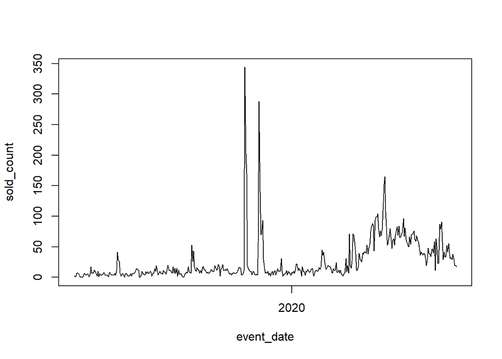

```r
plot(product.data$event_date,product.data$sold_count,type="l", xlab="event_date", ylab="sold_count")
```

```r
product.data[,lag2_forecast:=shift(sold_count,2)]
product.data[,lag7_forecast:=shift(sold_count,7)]
product.data[,lag1_forecast:=shift(sold_count,1)]
lr_model = lm(sold_count~lag2_forecast+lag7_forecast+lag1_forecast, product.data)
product.data[,lr_forecast:=predict(lr_model,product.data)]
product.data[,list(sold_count,lr_forecast)]
```

```
##      sold_count lr_forecast
##   1:          2          NA
##   2:          2          NA
##   3:          1          NA
##   4:          7          NA
##   5:          7          NA
##  ---
## 429:         38    30.86113
## 430:         29    35.60570
## 431:         20    31.40279
## 432:         19    23.58108
## 433:         17    21.76826
```

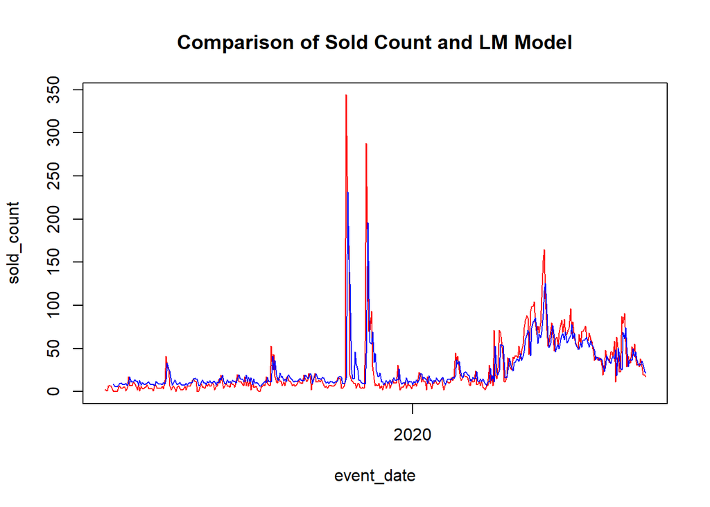

```r
plot(product.data$event_date,product.data$sold_count,type="l",col="red",xlab="event_date",ylab="sold_count",main="Comparison of Sold Count and LM Model")
lines(product.data$event_date,product.data$lr_forecast,type="l",col="blue")
```

```r
may = product.data[which(product.data$event_date >= "2020-04-27"),]
may_ts=ts(may[,-2],start=c(2020,4),frequency=365)
may_ts=may_ts[,3]
data_ts=ts(may[,c("sold_count")])
arima_model= auto.arima(data_ts)
summary(arima_model)
```

```
## Series: data_ts
## ARIMA(1,1,1)
##
## Coefficients:
##          ar1      ma1
##       0.2949  -0.7867
## s.e.  0.1812   0.1217
##
## sigma^2 estimated as 221.3:  log likelihood=-283.44
## AIC=572.88   AICc=573.25   BIC=579.58
##
## Training set error measures:
##                     ME     RMSE      MAE       MPE     MAPE      MASE
## Training set -2.135913 14.55424 11.19547 -15.98375 29.01835 0.9716823
##                     ACF1
## Training set -0.04717267
```

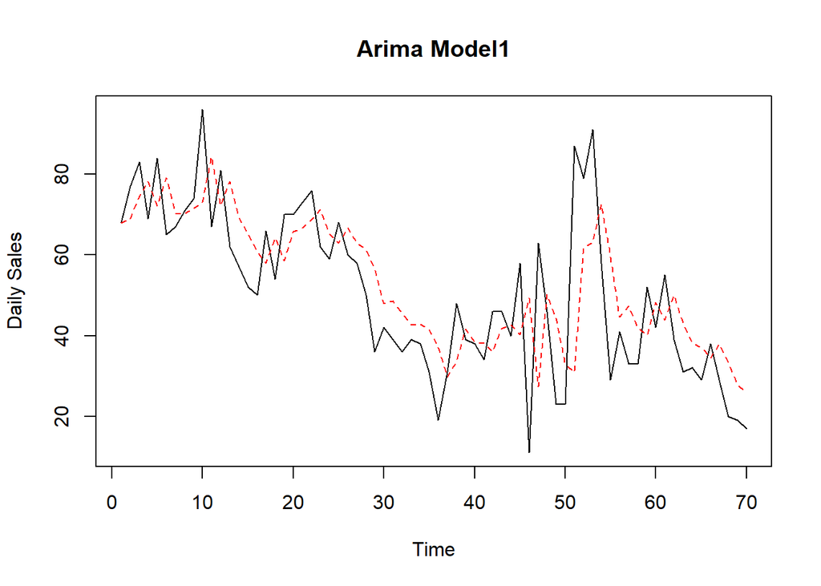

```r
model_fitted = data_ts - residuals(arima_model)
ts.plot(data_ts, xlab = "Time", ylab = "Daily Sales",main="Arima Model1")
points(model_fitted, type = "l", col = 2, lty = 2)
```

```r
forecast = forecast (arima_model, h=5)


fc = ses(may_ts, h=5)
summary(fc)
```

```
##
## Forecast method: Simple exponential smoothing
##
## Model Information:
## Simple exponential smoothing
##
## Call:
##  ses(y = may_ts, h = 5)
##
##   Smoothing parameters:
##     alpha = 0.4168
##
##   Initial states:
##     l = 73.2189
##
##   sigma:  15.0185
##
##      AIC     AICc      BIC
## 680.6654 681.0291 687.4109
##
## Error measures:
##                     ME     RMSE      MAE       MPE     MAPE MASE       ACF1
## Training set -1.789764 14.80243 11.24231 -14.98382 28.84957  NaN 0.08202261
##
## Forecasts:
##           Point Forecast      Lo 80    Hi 80      Lo 95    Hi 95
## 2020.2000       20.99784  1.7508141 40.24487  -8.437946 50.43363
## 2020.2027       20.99784  0.1457372 41.84994 -10.892699 52.88838
## 2020.2055       20.99784 -1.3443259 43.34001 -13.171554 55.16723
## 2020.2082       20.99784 -2.7410429 44.73672 -15.307648 57.30333
## 2020.2110       20.99784 -4.0600279 46.05571 -17.324862 59.32054
```

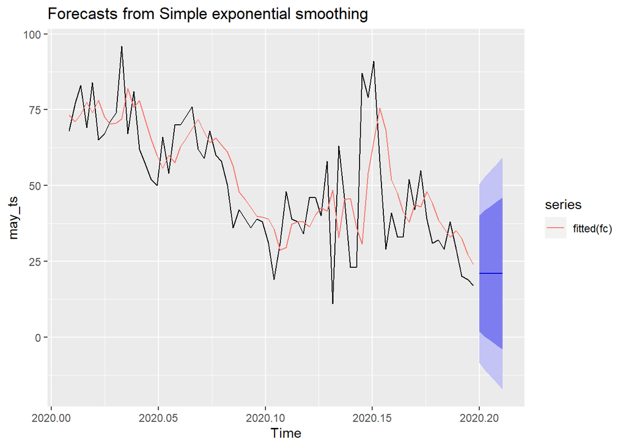

```r
autoplot(fc)+autolayer(fitted(fc))
```

*The number of sales of product 85004 has increased since April. So that, our model is set up based on this data.The linear model is set up based on the sold counts on the last day, two days ago and one week ago.When making predictions, these three models were taken into consideration. And also, the average number of last three days sold counts was calculated. The predictions were made based on the four different forecasts.

*We don’t build any model to predict sold counts of coat and bkini. Because, most of the days there were zero sales and in the remaining days sales could not reach double digits.

***CONCLUSION

*Arima and linear regression models are built for each product. Performance tests are applied to the models. According to results of the tests it is decided to use which one of these models.